# Animal Models

## 4.2 Camparing models accounting for inbreeding using or not Cholesky decomposition

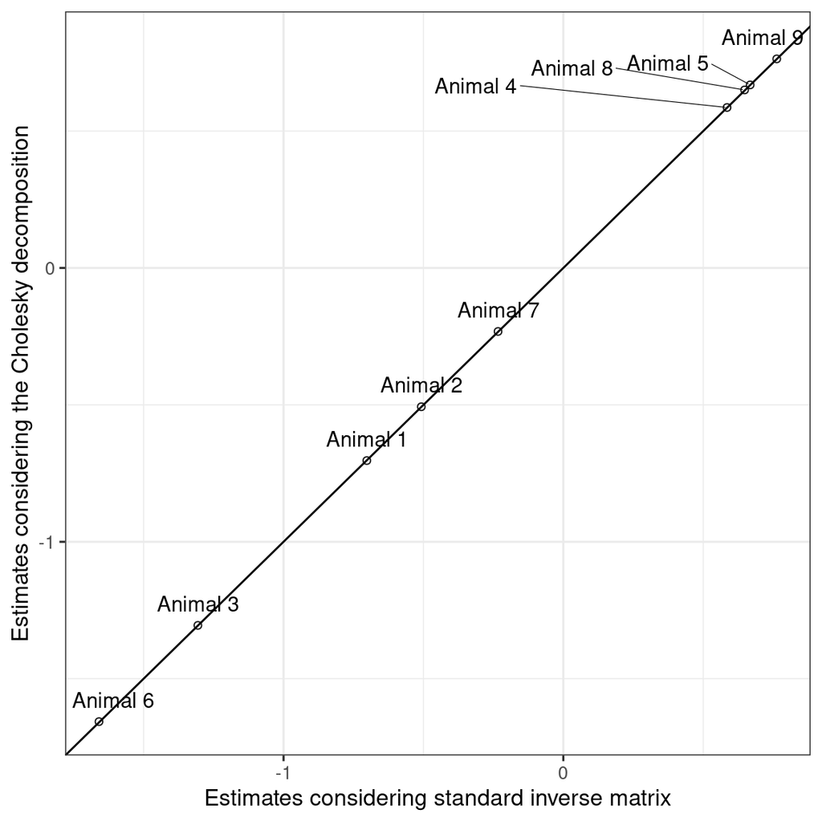

```r
#-----------------------------------------------------------------------
# model 1 - Inb: estimates using the standard inverse matrix
# model 2 - CholInb: estimates using Cholesky decomposition
#-----------------------------------------------------------------------
data_comp <- data.frame(CholInb = estimatesCholInbreeding[c(1:9), 1],
                        Inb = estimatesInbreeding[c(1:9), 1],
                        Animal = gl(n = 9,  k = 1,
                                    labels = paste0("Animal ", 1:9)))

data_comp %>%
  ggplot(aes(y = CholInb,  x = Inb,  label = Animal)) +
  geom_point(shape = 1,  alpha = 0.9) +
  geom_abline(intercept = 0,  slope = 1) +
  geom_text_repel(
    nudge_y      = 0.05,
    direction    = "x",
    vjust        = 0,
    segment.size = 0.2) +
  ylab("Estimates considering the Cholesky decomposition") +
  xlab("Estimates considering standard inverse matrix") +
  theme_bw(base_size = 12)
```

```r
data_diff <- data.frame(
  Parameter = rownames(estimatesInbreeding)[c(1:9, 11:12)],
  Difference = estimatesCholInbreeding[c(1:9,  11, 12), 1] -
    estimatesInbreeding[c(1:9,  11, 12), 1],
  Ratio = estimatesCholInbreeding[c(1:9,  11, 12), 1]/
    estimatesInbreeding[c(1:9,  11, 12), 1])

data_diff %>%
  kbl(
    caption = "Difference and ratio between parameter estimates",
    digits = 4,
  ) %>%
  kable_paper("hover", full_width = F) %>%
  column_spec(2, color = "white",
              background = spec_color(data_diff[,2], end = 0.7),
              popover = paste("am:", data_diff[,2])) %>%
  column_spec(3, color = "white",
              background = spec_color(data_diff[,2], end = 0.7),
              popover = paste("am:", data_diff[,3]))
```

Table 4.1: Difference and ratio between parameter estimates

| Parameter | Difference | Ratio |
| --- | --- | --- |
| a[1] | -0.0011 | 1.0016 |
| a[2] | 0.0007 | 0.9986 |
| a[3] | 0.0008 | 0.9994 |
| a[4] | 0.0009 | 1.0015 |
| a[5] | 0.0008 | 1.0012 |
| a[6] | 0.0027 | 0.9984 |
| a[7] | 0.0014 | 0.9940 |
| a[8] | 0.0023 | 1.0036 |
| a[9] | 0.0008 | 1.0010 |
| b[1] | -0.0008 | 1.0000 |
| b[2] | -0.0015 | 1.0000 |

# 5 Reording pedigree information

Generally, the internal ordering of the pedigree is often of little importance for end-users. However, it is essential to mention the function `AnimalModelBUGSData` assumes the pedigree is ordering so parents come before offspring (you can type `?animalModels::AnimalModelBUGSData` in `R` for more details). The argument `reorder` from `AnimalModelBUGSData` function is logical, where setting `reorder=TRUE` causes a reordering of the pedigree (via `orderPed()` from the package `MasterBayes`) for the internal calculations, while the data is returned in the original order; if the pedigree is not ordered, inbreeding can not be `TRUE` because the $\boldsymbol{A}$ matrix will bias the analysis.

## 5.1 Example 4: Reording pedigree information to evaluate inbreeding correctly

Here, we are inducing a wrong order in the pedigree and trying to come back into the original pedigree using the function `orderPed()`.

```r
## Prepair data
ord <- c(4, 6, 1, 9, 2, 5, 7, 8, 3)
(tmp <- AnimalModelBUGSData(ped=example[ord, ], Chol=TRUE,
                            reorder=TRUE, intercept = FALSE))
```

```
## $nI
## [1] 9
##
## $nY
## [1] 6
##
## $y
## [1] 101  93 109 105 106  98
##
## $nU
## [1] 10
##
## $id
## [1] 4 6 1 9 2 5 7 8 3
##
## $fid
## [1]  2  2 10  7 10  4  5 10  2
##
## $mid
## [1] 10  3 10  8 10  3  6 10  1
##
## $idy
## [1] 4 6 9 2 5 3
##
## $wsqr
## [1] 1.0000000 1.0000000 0.7071068 0.8660254 0.7071068 0.7071068 0.6373774
## [8] 1.0000000 0.6555055
##
## $x
##   group1 group2
## 1      0      1
## 2      0      1
## 3      1      0
## 4      1      0
## 5      0      1
## 6      1      0
## attr(,"assign")
## [1] 1 1
## attr(,"contrasts")
## attr(,"contrasts")$group
## [1] "contr.treatment"
##
##
## $nB
## [1] 2
```

```r
## Set precisions
tmp$tau2a <- 1 / sigma2a
tmp$tau2e <- 1 / sigma2e
```

```r
AnimalModelBUGSChol <- function()
{
  ## Additive genetic values
  for(k in 1:nI) {
    u[k] ~ dnorm(0, tau2a)
    a[id[k]] <- u[k] * wsqr[id[k]] + 0.5 * (a[fid[k]] + a[mid[k]])
  }
  a[nU] <- 0 # NULL (zero) holder

  ## Location priors
  for(j in 1:nB) { b[j] ~ dnorm(0, 1.0E-6) }

  ## Phenotypes
  for(i in 1:nY) {
    y[i] ~ dnorm(mu[i], tau2e)
    mu[i] <- inprod(x[i, ], b[]) + a[idy[i]]
  }
}
```

```r
writeJags(model = AnimalModelBUGSChol, filename = "model.txt")
#-----------------------------------------------------------------------
# Model
#-----------------------------------------------------------------------
jags_params <- c("a", "b")
runJagsOut <- run.jags(method = "parallel",
                       model = filename,
                       monitor = jags_params,
                       data = tmp,
                       n.chains = nChains,
                       burnin = nBurninSteps,
                       sample = ceiling(nUseSteps/nChains),
                       thin = nThinSteps,
                       summarise = FALSE,
                       plots = FALSE,
                       inits = initfunctionChol)
```

```
## Calling 3 simulations using the parallel method...
## Following the progress of chain 1 (the program will wait for all chains
## to finish before continuing):
## Welcome to JAGS 4.3.0 on Tue May  2 07:12:32 2023
## JAGS is free software and comes with ABSOLUTELY NO WARRANTY
## Loading module: basemod: ok
## Loading module: bugs: ok
## . . Reading data file data.txt
## . Compiling model graph
## . Reading parameter file inits1.txt
## . Initializing model
## . Adaptation skipped: model is not in adaptive mode.
## . Updating 30000
## -------------------------------------------------| 30000
## ************************************************** 100%
## . . . Updating 300000
## -------------------------------------------------| 300000
## ************************************************** 100%
## . . . . Updating 0
## . Deleting model
## .
## All chains have finished
## Note: the model did not require adaptation
## Simulation complete.  Reading coda files...
## Coda files loaded successfully
## Finished running the simulation
```

```r
# coda samples - MCMC
coda_samples <- as.mcmc.list(runJagsOut)

# parameter estimates
estimatesCholInbreedingOrd <- MCMCsummary(coda_samples, round = 4)
estimatesCholInbreedingOrd
```

|  | mean | sd | 2.5% | 50% | 97.5% | Rhat | n.eff |
| --- | --- | --- | --- | --- | --- | --- | --- |
| a[1] | -0.6992 | 0.5634 | -1.7945 | -0.6997 | 0.4042 | 1 | 60000 |
| a[2] | -0.5061 | 0.5523 | -1.5851 | -0.5074 | 0.5778 | 1 | 59520 |
| a[3] | -1.3064 | 0.5480 | -2.3809 | -1.3080 | -0.2284 | 1 | 59522 |
| a[4] | 0.5872 | 0.5572 | -0.4992 | 0.5843 | 1.6870 | 1 | 60000 |
| a[5] | 0.6687 | 0.5980 | -0.5048 | 0.6698 | 1.8466 | 1 | 59300 |
| a[6] | -1.6567 | 0.6104 | -2.8592 | -1.6590 | -0.4655 | 1 | 61136 |
| a[7] | -0.2317 | 0.6437 | -1.4961 | -0.2315 | 1.0272 | 1 | 59052 |
| a[8] | 0.6501 | 0.5650 | -0.4646 | 0.6530 | 1.7563 | 1 | 61363 |
| a[9] | 0.7644 | 0.5521 | -0.3146 | 0.7657 | 1.8502 | 1 | 58061 |
| a[10] | 0.0000 | 0.0000 | 0.0000 | 0.0000 | 0.0000 | NaN | 0 |

[output cut: 2 more lines]

## 5.2 Comparing animal models using Cholesky decomposition

- `estimatesCholInbreeding` is related to the original pedigree, while `estimatesCholInbreedingOrd` contains estimates from data where the pedigree was re-ordered.

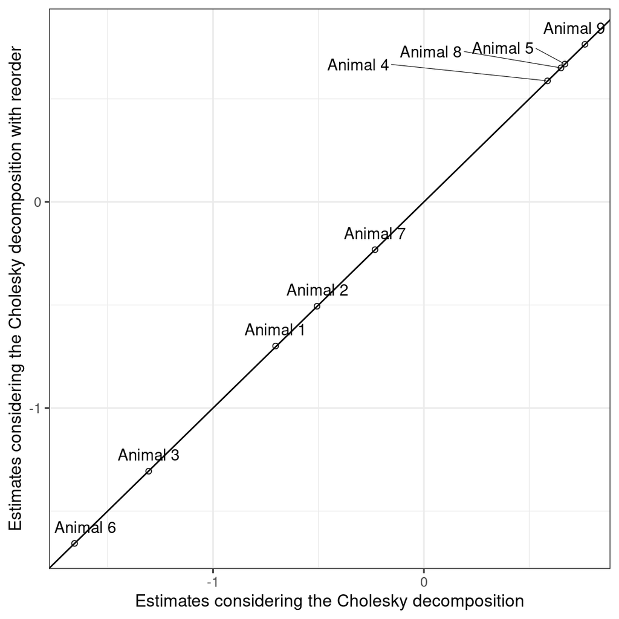

```r
data_comp <-
  data.frame(CholInb = estimatesCholInbreeding[c(1:9), 1],
             CholInbOrd = estimatesCholInbreedingOrd[c(1:9), 1],
             Animal = gl(n = 9,  k = 1,
                         labels = paste0("Animal ", 1:9)))

data_comp %>%
  ggplot(aes(y = CholInbOrd,  x = CholInb,  label = Animal)) +
  geom_point(shape = 1,  alpha = 0.9) +
  geom_abline(intercept = 0,  slope = 1) +
  geom_text_repel(
    nudge_y      = 0.05,
    direction    = "x",
    vjust        = 0,
    segment.size = 0.2) +
  ylab("Estimates considering the Cholesky decomposition with reorder") +
  xlab("Estimates considering the Cholesky decomposition") +
  theme_bw(base_size = 12)
```

```r
data_diff <- data.frame(
  Parameter = rownames(estimatesCholInbreeding)[c(1:9, 11:12)],
  Difference = estimatesCholInbreedingOrd[c(1:9,  11, 12), 1] -
    estimatesCholInbreeding[c(1:9,  11, 12), 1],
  Ratio = estimatesCholInbreedingOrd[c(1:9,  11, 12), 1]/
    estimatesCholInbreeding[c(1:9,  11, 12), 1])

data_diff %>%
  kbl(
    caption = "Difference and ratio between parameter estimates",
    digits = 4,
  ) %>%
  kable_paper("hover", full_width = F) %>%
  column_spec(2, color = "white",
              background = spec_color(data_diff[,2], end = 0.7),
              popover = paste("am:", data_diff[,2])) %>%
  column_spec(3, color = "white",
              background = spec_color(data_diff[,2], end = 0.7),
              popover = paste("am:", data_diff[,3]))
```

Table 5.1: Difference and ratio between parameter estimates

| Parameter | Difference | Ratio |
| --- | --- | --- |
| a[1] | 0.0042 | 0.9940 |
| a[2] | 0.0008 | 0.9984 |
| a[3] | -0.0011 | 1.0008 |
| a[4] | 0.0012 | 1.0020 |
| a[5] | 0.0002 | 1.0003 |
| a[6] | 0.0001 | 0.9999 |
| a[7] | 0.0002 | 0.9991 |
| a[8] | 0.0000 | 1.0000 |
| a[9] | 0.0009 | 1.0012 |
| b[1] | -0.0002 | 1.0000 |
| b[2] | -0.0005 | 1.0000 |

- Argument `reorder` is recovering the order of pedigree, and, consequently, parameter estimates is quite the same.

# 6 Additional parameterizarions

Additionally, two other parameterizations of the animal model are interesting which involve the incorporation of NRM into the design matrix $\mathbf{Z}$ to remove dependence between additive genetic values, e.g.,
$$\mathbf{u}|\sigma_{a}^{2}\sim N\left(\mathbf{0},\mathbf{I}\sigma_{a}^{2}\right).$$
One approach is to use left Cholesky factor (Quaas, Anderson, and Gilmour 1984a)
$$\mathbf{Z}^{*}=\mathbf{Z}\mathbf{L}=\mathbf{Z}\mathbf{T}\mathbf{W}^{\frac{1}{2}}$$
, where original $\mathbf{a}$ can be computed using $\mathbf{a}=\mathbf{T}\mathbf{W}^{\frac{1}{2}}\mathbf{u}$ or more efficiently with solving
$$\mathbf{T}^{-1}\mathbf{a}=\mathbf{W}^{\frac{1}{2}}\mathbf{u}$$
due to the sparseness of $\mathbf{T}^{-1}$ (e.g. ). In a similar manner, Waldmann et al. (2008a) used a singular value decomposition (SVD) of NRM, i.e., $\mathbf{A}=\mathbf{U}\mathbf{S}\mathbf{U}^{T}$, where $\mathbf{U}$ is a dense orthonormal matrix
$$\left(\mathbf{U}\mathbf{U}^{T}=\mathbf{I}\right)$$
and $\mathbf{S}$ is a diagonal matrix. Then the parameterization is
$$\mathbf{Z}^{*}=\mathbf{Z}\mathbf{U}\mathbf{S}^{\frac{1}{2}}$$
and
$$\mathbf{a}=\mathbf{U}\mathbf{S}^{\frac{1}{2}}\mathbf{u}.$$
JAGS implementation for such a parameterization can be see bellow:

```r
AnimalModelBUGSZStarVar <- function()
{
  ## Variance priors
  tau2e ~ dgamma(0.001, 0.001)
  tau2a ~ dgamma(0.001, 0.001)
  sigma2e <- 1 / tau2e
  sigma2a <- 1 / tau2a

  ## Transformed additive genetic values
  for(k in 1:nI) { u[k] ~ dnorm(0, tau2a) }

  ## Location priors
  for(j in 1:nB) { b[j] ~ dnorm(0, 1.0E-6) }

  ## Phenotypes
  for(i in 1:nY) {
    y[i] ~ dnorm(mu[i], tau2e)
    mu[i] <-  inprod(x[i, ], b[]) + inprod(ZStar[i, ], u[])
  }
}
```

The reason for the simplicity of the algorithm is that it assumes that additive genetic values are independent and fitted with a homogenous variance (precision), while pedigree information is incorporated into the design matrix $\mathbf{Z}^{*}$. However, this also implies that the entire dense matrix $\mathbf{Z}^{*}$ of order $nY\times nI$ must be passed to JAGS. Preliminary tests have shown that the CPU time is lengthy, making these two BUGS language approaches only practical for pedigrees with a small number of members. The same conclusion applies to the augmented parameterization of the mixed model proposed by Harville (1986a). Therefore, these approaches were not evaluated for speed and mixing.

## 6.1 Example 5: Animal model using $\mathbf{Z}^{*}$ via Cholesky

```r
#=======================================================================
### --- Animal model - ZStar via Cholesky ---
#=======================================================================
## Prepair data
(tmp <- AnimalModelBUGSData(ped=example, ZChol=TRUE, intercept = FALSE))
```

```
## $nI
## [1] 6
##
## $nY
## [1] 6
##
## $y
## [1] 105  98 101 106  93 109
##
## $ZStar
##        2         3         4         5         6         9
## 1 1.0000 0.0000000 0.0000000 0.0000000 0.0000000 0.0000000
## 2 0.5000 0.8660254 0.0000000 0.0000000 0.0000000 0.0000000
## 3 0.5000 0.0000000 0.8660254 0.0000000 0.0000000 0.0000000
## 4 0.5000 0.4330127 0.4330127 0.7071068 0.0000000 0.0000000
## 5 0.7500 0.4330127 0.0000000 0.0000000 0.7071068 0.0000000
## 6 0.3125 0.2165064 0.1082532 0.1767767 0.1767767 0.8838835
##
## $id
## [1] 2 3 4 5 6 9
##
## $fact
## 6 x 6 sparse Matrix of class "dtCMatrix"
##   2         3         4         5             6         9
## 2 1 0.5000000 0.5000000 0.5000000  7.500000e-01 0.3125000
## 3 . 0.8660254 0.0000000 0.4330127  4.330127e-01 0.2165064
## 4 . .         0.8660254 0.4330127  0.000000e+00 0.1082532
## 5 . .         .         0.7071068 -3.925231e-17 0.1767767
## 6 . .         .         .          7.071068e-01 0.1767767
## 9 . .         .         .          .            0.8838835
##
## $x
##   group1 group2
## 1      1      0
## 2      1      0
## 3      0      1
## 4      0      1
## 5      0      1
## 6      1      0
## attr(,"assign")
## [1] 1 1
## attr(,"contrasts")
## attr(,"contrasts")$group
## [1] "contr.treatment"
##
##
## $nB
## [1] 2
```

```r
## Set precisions
tmp$tau2a <- 1 / sigma2a
tmp$tau2e <- 1 / sigma2e

## Store the right Cholesky factor and id for later use and remove it -
## this is mandatory!
U <- tmp$fact
tmp$fact <- NULL
id <- tmp$id
tmp$id <- NULL
```

```r
AnimalModelBUGSZStar <- function()
{
  ## Transformed additive genetic values
  for(k in 1:nI) { u[k] ~ dnorm(0, tau2a) }

  ## Location priors
  for(j in 1:nB) { b[j] ~ dnorm(0, 1.0E-6) }

  ## Phenotypes
  for(i in 1:nY) {
    y[i] ~ dnorm(mu[i], tau2e)
    mu[i] <- inprod(x[i, ], b[]) + inprod(ZStar[i, ], u[])
  }
}
```

```r
#-----------------------------------------------------------------------
# Model
#-----------------------------------------------------------------------
writeJags(model = AnimalModelBUGSZStar, filename = "model.txt")
  initfunctionZstar <- function(chain) {
    nI <- 6
    nB <- 2
    nc <- 3
    stopifnot(chain %in% 1:nc)
    u <- b <- list()
    for(i in 1:nc){
      u[[i]] <- rnorm(nI,0,2)
      b[[i]] <- rnorm(nB,100,10)
    }
    .RNG.name <- rep("base::Super-Duper", 3)[chain]
    .RNG.seed = seq(1,3,1)[chain]
    return(list(u = u[[chain]], b = b[[chain]],
                .RNG.seed = .RNG.seed, .RNG.name = .RNG.name))
  }

jags_params <- c("u", "b")
runJagsOut <- run.jags(method = "parallel",
                       model = filename,
                       monitor = jags_params,
                       data = tmp,
                       n.chains = nChains,
                       burnin = nBurninSteps,
                       sample = ceiling(nUseSteps/nChains),
                       thin = nThinSteps,
                       summarise = FALSE,
                       plots = FALSE,
                       inits = initfunctionZstar)
```

```
## Calling 3 simulations using the parallel method...
## Following the progress of chain 1 (the program will wait for all chains
## to finish before continuing):
## Welcome to JAGS 4.3.0 on Tue May  2 07:12:36 2023
## JAGS is free software and comes with ABSOLUTELY NO WARRANTY
## Loading module: basemod: ok
## Loading module: bugs: ok
## . . Reading data file data.txt
## . Compiling model graph
## . Reading parameter file inits1.txt
## . Initializing model
## . Adaptation skipped: model is not in adaptive mode.
## . Updating 30000
## -------------------------------------------------| 30000
## ************************************************** 100%
## . . . Updating 300000
## -------------------------------------------------| 300000
## ************************************************** 100%
## . . . . Updating 0
## . Deleting model
## .
## All chains have finished
## Note: the model did not require adaptation
## Simulation complete.  Reading coda files...
## Coda files loaded successfully
## Finished running the simulation
```

```r
# coda samples - MCMC
coda_samples <- as.mcmc.list(runJagsOut)

# parameter estimates
estimatesCholInbreedingZstar <- MCMCsummary(coda_samples, round = 4)
estimatesCholInbreedingZstar
```

|  | mean | sd | 2.5% | 50% | 97.5% | Rhat | n.eff |
| --- | --- | --- | --- | --- | --- | --- | --- |
| u[1] | -0.5047 | 0.5551 | -1.5976 | -0.5047 | 0.5805 | 1 | 60000 |
| u[2] | -1.2139 | 0.5336 | -2.2651 | -1.2138 | -0.1671 | 1 | 60000 |
| u[3] | 0.9745 | 0.5479 | -0.0937 | 0.9762 | 2.0519 | 1 | 60756 |
| u[4] | 1.4581 | 0.5496 | 0.3840 | 1.4571 | 2.5420 | 1 | 60000 |
| u[5] | -1.0635 | 0.5476 | -2.1342 | -1.0650 | 0.0115 | 1 | 59004 |
| u[6] | 1.1441 | 0.5387 | 0.0868 | 1.1459 | 2.2006 | 1 | 60000 |
| b[1] | 104.3479 | 0.7279 | 102.9230 | 104.3520 | 105.7670 | 1 | 60000 |
| b[2] | 100.1322 | 0.7558 | 98.6593 | 100.1290 | 101.6170 | 1 | 60000 |

```r
#-----------------------------------------------------------------------
# Obtaining the a estimates
#-----------------------------------------------------------------------
tmp2 <- coda_samples[, 1:6]
tmp3 <- mcpar(tmp2[[1]])
tmp3 <- mcmc(data=as.matrix(as.matrix(tmp2) %*% U),
             start=tmp3[1], end=tmp3[2], thin=tmp3[3])
dimnames(tmp3)[[2]] <- paste("a[", id, "]", sep="")
Z_est <- c(NA, summary(tmp3)[[1]][1:5, 1], rep(NA, 2),
           summary(tmp3)[[1]][6, 1], estimatesCholInbreedingZstar[7:8, 1])
summary(tmp3)
```

```
##
## Iterations = 31001:330986
## Thinning interval = 15
## Number of chains = 1
## Sample size per chain = 20000
##
## 1. Empirical mean and standard deviation for each variable,
##    plus standard error of the mean:
##
##         Mean     SD Naive SE Time-series SE
## a[2] -0.4990 0.5579 0.003945       0.003945
## a[3] -1.3017 0.5488 0.003880       0.003880
## a[4]  0.5932 0.5652 0.003997       0.003997
## a[5]  0.6793 0.5963 0.004216       0.004216
## a[6] -1.6511 0.6139 0.004341       0.004341
## a[9]  0.7700 0.5541 0.003918       0.003918
##
## 2. Quantiles for each variable:
##
##         2.5%     25%     50%     75%   97.5%
## a[2] -1.5898 -0.8762 -0.5011 -0.1174  0.5911
## a[3] -2.3589 -1.6783 -1.3022 -0.9269 -0.2217
## a[4] -0.5090  0.2093  0.5944  0.9716  1.7202
## a[5] -0.4772  0.2720  0.6784  1.0819  1.8484
## a[6] -2.8363 -2.0782 -1.6483 -1.2278 -0.4441
## a[9] -0.3100  0.3944  0.7695  1.1430  1.8527
```

## 6.2 Example 6: Animal model using $\mathbf{Z}^{*}$ via SVD

```r
#=======================================================================
# Animal model - ZStar via SVD
#=======================================================================
## Prepair data - Singular value decomposition (SVD)
(tmp <- AnimalModelBUGSData(ped=example, ZSVD = TRUE, intercept = FALSE))
```

```
## $nI
## [1] 6
##
## $nY
## [1] 6
##
## $y
## [1] 105  98 101 106  93 109
##
## $ZStar
##         [,1]        [,2]        [,3]       [,4]        [,5]         [,6]
## 1 -0.7892960  0.01857531  0.31341827  0.3765138  0.36968650 -0.002249664
## 2 -0.7778530  0.33628407  0.07299132 -0.4181467  0.04076382  0.316261898
## 3 -0.6331143 -0.69262952  0.09592374  0.1653480 -0.21297229  0.193732027
## 4 -0.8448040 -0.35766088 -0.12216732 -0.4280523  0.10464873 -0.272543393
## 5 -0.9357211  0.42566660  0.19264999  0.1578998 -0.31566949 -0.177596377
## 6 -0.5709971  0.11579885 -0.77399029  0.2403898  0.03206039  0.051738041
##
## $id
## [1] 2 3 4 5 6 9
##
## $fact
## $fact$u
##            [,1]        [,2]        [,3]       [,4]        [,5]         [,6]
## [1,] -0.4192585  0.01941162  0.35860591  0.4821170  0.68028671 -0.004535244
## [2,] -0.4131802  0.35142444  0.08351497 -0.5354269  0.07501244  0.637573034
## [3,] -0.3362979 -0.72381348  0.10975371  0.2117241 -0.39190561  0.390557056
## [4,] -0.4487432 -0.37376369 -0.13978101 -0.5481108  0.19257165 -0.549438042
## [5,] -0.4970366  0.44483120  0.22042565  0.2021869 -0.58088611 -0.358028146
## [6,] -0.3033024  0.12101241 -0.88558172  0.3078135  0.05899663  0.104302099
##
## $fact$d
## [1] 3.5441826 0.9156904 0.7638600 0.6098977 0.2953134 0.2460559
##
##
## $x
##   group1 group2
## 1      1      0
## 2      1      0
## 3      0      1
## 4      0      1
## 5      0      1
## 6      1      0
## attr(,"assign")
## [1] 1 1
## attr(,"contrasts")
## attr(,"contrasts")$group
## [1] "contr.treatment"
##
##
## $nB
## [1] 2
```

```r
## Set precisions
tmp$tau2a <- 1 / sigma2a
tmp$tau2e <- 1 / sigma2e

## Store the SVD factor and id for later use and remove it - this is
## mandatory!
svdUDV <- tmp$fact
tmp$fact <- NULL
id <- tmp$id
tmp$id <- NULL
```

```r
AnimalModelBUGSZStar <- function()
{
  ## Transformed additive genetic values
  for(k in 1:nI) { u[k] ~ dnorm(0, tau2a) }

  ## Location priors
  for(j in 1:nB) { b[j] ~ dnorm(0, 1.0E-6) }

  ## Phenotypes
  for(i in 1:nY) {
    y[i] ~ dnorm(mu[i], tau2e)
    mu[i] <- inprod(x[i, ], b[]) + inprod(ZStar[i, ], u[])
  }
}
```

```r
#-----------------------------------------------------------------------
# Model
#-----------------------------------------------------------------------
writeJags(model = AnimalModelBUGSZStar, filename = "model.txt")
jags_params <- c("u", "b")

runJagsOut <- run.jags(method = "parallel",
                       model = filename,
                       monitor = jags_params,
                       data = tmp,
                       n.chains = nChains,
                       burnin = nBurninSteps,
                       sample = ceiling(nUseSteps/nChains),
                       thin = nThinSteps,
                       summarise = FALSE,
                       plots = FALSE,
                       inits = initfunctionZstar)
```

```
## Calling 3 simulations using the parallel method...
## Following the progress of chain 1 (the program will wait for all chains
## to finish before continuing):
## Welcome to JAGS 4.3.0 on Tue May  2 07:12:40 2023
## JAGS is free software and comes with ABSOLUTELY NO WARRANTY
## Loading module: basemod: ok
## Loading module: bugs: ok
## . . Reading data file data.txt
## . Compiling model graph
## . Reading parameter file inits1.txt
## . Initializing model
## . Adaptation skipped: model is not in adaptive mode.
## . Updating 30000
## -------------------------------------------------| 30000
## ************************************************** 100%
## . . . Updating 300000
## -------------------------------------------------| 300000
## ************************************************** 100%
## . . . . Updating 0
## . Deleting model
## .
## All chains have finished
## Note: the model did not require adaptation
## Simulation complete.  Reading coda files...
## Coda files loaded successfully
## Finished running the simulation
```

```r
# coda samples - MCMC
coda_samples <- as.mcmc.list(runJagsOut)

# parameter estimates
estimatesZSVDInbreedingZstar <- MCMCsummary(coda_samples, round = 4)
estimatesZSVDInbreedingZstar
```

|  | mean | sd | 2.5% | 50% | 97.5% | Rhat | n.eff |
| --- | --- | --- | --- | --- | --- | --- | --- |
| u[1] | 0.4493 | 0.5715 | -0.6697 | 0.4460 | 1.5741 | 1 | 60000 |
| u[2] | -1.8680 | 0.5210 | -2.8872 | -1.8701 | -0.8455 | 1 | 62771 |
| u[3] | -1.5556 | 0.5202 | -2.5731 | -1.5554 | -0.5342 | 1 | 60551 |
| u[4] | 0.1477 | 0.5308 | -0.8953 | 0.1458 | 1.1954 | 1 | 60764 |
| u[5] | 0.8499 | 0.5599 | -0.2529 | 0.8497 | 1.9405 | 1 | 59536 |
| u[6] | -0.5966 | 0.5653 | -1.7043 | -0.5957 | 0.5157 | 1 | 60000 |
| b[1] | 104.3503 | 0.7285 | 102.9140 | 104.3530 | 105.7690 | 1 | 60000 |
| b[2] | 100.1354 | 0.7593 | 98.6572 | 100.1360 | 101.6320 | 1 | 60000 |

```r
#-----------------------------------------------------------------------
# Obtaining the a estimates
#-----------------------------------------------------------------------
tmp2 <- coda_samples[, 1:6]
tmp3 <- mcpar(tmp2[[1]])
tmp3 <- mcmc(data=as.matrix(t(svdUDV$u %*% Diagonal(x=sqrt(svdUDV$d)) %*% t(as.matrix(tmp2[[1]])))),
             start=tmp3[1], end=tmp3[2], thin=tmp3[3])
dimnames(tmp3)[[2]] <- paste("a[", id, "]", sep="")
Z_est_ZSVD <- c(NA, summary(tmp3)[[1]][1:5, 1], rep(NA, 2),
           summary(tmp3)[[1]][6, 1], estimatesZSVDInbreedingZstar[7:8, 1])
summary(tmp3)
```

```
##
## Iterations = 31001:330986
## Thinning interval = 15
## Number of chains = 1
## Sample size per chain = 20000
##
## 1. Empirical mean and standard deviation for each variable,
##    plus standard error of the mean:
##
##         Mean     SD Naive SE Time-series SE
## a[2] -0.5083 0.5552 0.003926       0.003926
## a[3] -1.3113 0.5516 0.003900       0.003900
## a[4]  0.5870 0.5602 0.003961       0.003961
## a[5]  0.6626 0.5985 0.004232       0.004232
## a[6] -1.6592 0.6137 0.004339       0.004339
## a[9]  0.7630 0.5547 0.003922       0.003922
##
## 2. Quantiles for each variable:
##
##         2.5%     25%     50%     75%   97.5%
## a[2] -1.6054 -0.8819 -0.5073 -0.1271  0.5715
## a[3] -2.3821 -1.6825 -1.3128 -0.9388 -0.2430
## a[4] -0.5081  0.2055  0.5903  0.9675  1.6724
## a[5] -0.4926  0.2493  0.6585  1.0682  1.8430
## a[6] -2.8402 -2.0805 -1.6599 -1.2444 -0.4523
## a[9] -0.3339  0.3907  0.7638  1.1316  1.8711
```

## 6.3 Comparing parameters estimate using $\mathbf{Z}^{*}$ via Cholesky and SVD

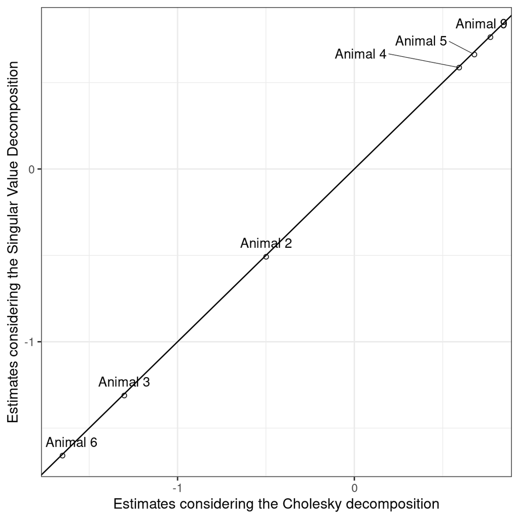

```r
data_comp <-
  data.frame(CholInb = Z_est[1:9],
             SVDInb = Z_est_ZSVD[1:9],
             Animal = gl(n = 9,  k = 1,
                         labels = paste0("Animal ", 1:9)))

data_comp %>%
  ggplot(aes(y = SVDInb,  x = CholInb,  label = Animal)) +
  geom_point(shape = 1,  alpha = 0.9) +
  geom_abline(intercept = 0,  slope = 1) +
  geom_text_repel(
    nudge_y      = 0.05,
    direction    = "x",
    vjust        = 0,
    segment.size = 0.2) +
  ylab("Estimates considering the Singular Value Decomposition") +
  xlab("Estimates considering the Cholesky decomposition") +
  theme_bw(base_size = 12)
```

```r
data_diff <- data.frame(
  Parameter = c(paste0("a[",1:9,"]"),paste0("b[",1:2,"]")),
  Difference = Z_est_ZSVD[1:11] - Z_est[1:11],
  Ratio = Z_est_ZSVD[1:11]/Z_est[1:11])

data_diff %>%
  kbl(
    caption = "Difference and ratio between parameter estimates",
    digits = 4,
  ) %>%
  kable_paper("hover", full_width = F) %>%
  column_spec(2, color = "white",
              background = spec_color(data_diff[,2], end = 0.7),
              popover = paste("am:", data_diff[,2])) %>%
  column_spec(3, color = "white",
              background = spec_color(data_diff[,2], end = 0.7),
              popover = paste("am:", data_diff[,3]))
```

Table 6.1: Difference and ratio between parameter estimates

| Parameter | Difference | Ratio |
| --- | --- | --- |
| a[1] | NA | NA |
| a[2] | -0.0093 | 1.0187 |
| a[3] | -0.0097 | 1.0075 |
| a[4] | -0.0062 | 0.9896 |
| a[5] | -0.0168 | 0.9753 |
| a[6] | -0.0082 | 1.0050 |
| a[7] | NA | NA |
| a[8] | NA | NA |
| a[9] | -0.0069 | 0.9910 |
| b[1] | 0.0024 | 1.0000 |
| b[2] | 0.0032 | 1.0000 |

# 7 Model estimates summary

Consider the following general models:

- Model 1 (m1): AM without accounting for inbreeding
- Model 2 (m2): AM accounting for inbreeding
- Model 3 (m3): AM accounting for inbreeding and Cholesky Decomposition
- Model 4 (m4): AM accounting for inbreeding, Cholesky Decomposition, and Reording Pedigree
- Model 5 (m5): AM accounting for inbreeding, Cholesky Decomposition, and $\mathbf{Z}^{*}$
- Model 6 (m6): AM accounting for inbreeding, SVD Decomposition, and $\mathbf{Z}^{*}$

## 7.1 Variance considered as known

Table 7.1: Parameter estimates from different models considering variance known

| Parameters | m1 | m2 | m3 | m4 | m5 | m6 |
| --- | --- | --- | --- | --- | --- | --- |
| a[1] | -0.6997 | -0.7023 | -0.7034 | -0.6992 | NA | NA |
| a[2] | -0.4985 | -0.5076 | -0.5069 | -0.5061 | -0.4990 | -0.5083 |
| a[3] | -1.2976 | -1.3061 | -1.3053 | -1.3064 | -1.3017 | -1.3113 |
| a[4] | 0.5880 | 0.5851 | 0.5860 | 0.5872 | 0.5932 | 0.5870 |
| a[5] | 0.6708 | 0.6677 | 0.6685 | 0.6687 | 0.6793 | 0.6626 |
| a[6] | -1.6537 | -1.6595 | -1.6568 | -1.6567 | -1.6511 | -1.6592 |
| a[7] | -0.1737 | -0.2333 | -0.2319 | -0.2317 | NA | NA |
| a[8] | 0.6372 | 0.6478 | 0.6501 | 0.6501 | NA | NA |
| a[9] | 0.8675 | 0.7627 | 0.7635 | 0.7644 | 0.7700 | 0.7630 |
| b[1] | 104.3131 | 104.3539 | 104.3531 | 104.3529 | 104.3479 | 104.3503 |
| b[2] | 100.1340 | 100.1380 | 100.1365 | 100.1360 | 100.1322 | 100.1354 |
| sigma2a | 0.3333 | 0.3333 | 0.3333 | 0.3333 | 0.3333 | 0.3333 |
| sigma2e | 1.0000 | 1.0000 | 1.0000 | 1.0000 | 1.0000 | 1.0000 |

## 7.2 Variance considered as unknown

Table 7.2: Parameter estimates from different models considering variance unknown

| Parameters | m1 | m2 | m3 | m4 | m5 | m6 |
| --- | --- | --- | --- | --- | --- | --- |
| a[1] | -2.0188 | -2.0454 | -2.0251 | -2.0226 | NA | NA |
| a[2] | 0.1436 | 0.0861 | 0.0482 | 0.1378 | -0.0475 | 0.2556 |
| a[3] | -2.9251 | -2.9968 | -3.0607 | -3.0535 | -3.0616 | -2.9245 |
| a[4] | 0.9094 | 0.8918 | 0.8190 | 0.8908 | 0.6421 | 0.8695 |
| a[5] | 2.9099 | 2.9109 | 2.8608 | 2.9507 | 2.6269 | 2.9491 |
| a[6] | -3.1429 | -3.1715 | -3.2691 | -3.2944 | -3.3911 | -3.2606 |
| a[7] | 0.5561 | 0.4647 | 0.3962 | 0.4076 | NA | NA |
| a[8] | 1.3607 | 1.4729 | 1.4568 | 1.5443 | NA | NA |
| a[9] | 2.2538 | 2.1805 | 2.1897 | 2.2806 | 2.0146 | 2.3541 |
| b[1] | 104.1735 | 104.2421 | 104.2664 | 104.2121 | 104.2732 | 104.3421 |
| b[2] | 99.7614 | 99.7726 | 99.8482 | 99.8105 | 99.8809 | 100.0086 |
| sigma2a | 66.3164 | 67.5702 | 67.6482 | 66.4938 | 76.5733 | 73.9889 |
| sigma2e | 42.3992 | 42.2566 | 42.2971 | 41.3676 | 42.4762 | 42.7078 |

# 8 NIMBLE implementation

The NIMBLE implementation of the Animal model offers a powerful and flexible tool for quantitative geneticists. The code provided below demonstrates how to account for inbreeding and use Cholesky decomposition of NRM. This approach can be extended to other animal models, making it a versatile tool for various research questions.

One advantage of using NIMBLE is its ability to handle missing data, which is a common issue in many data sets. NIMBLE allows users to specify models with missing values, and it can impute them during the MCMC sampling process.

Another advantage of NIMBLE is its flexibility in specifying prior distributions. Users can choose from a wide range of prior distributions, including informative priors or non-informative priors, depending on the research question and available knowledge. This flexibility enables users to perform sensitivity analyses and assess the robustness of their conclusions.

Furthermore, NIMBLE provides a user-friendly interface for specifying models, data, and priors. This interface makes it easy for users to construct complex models without the need for specialized programming skills. Additionally, NIMBLE offers fast computation and efficient sampling algorithms, making it suitable for large data sets.

```r
library(parallel)

# NIMBLE function
run_MCMC <- function(seed = sample(1:1e5, 1),  data) {
  library(nimble)
  sigma2a <- 1/3
  sigma2e <- 1
  nimble_params <- c("a", "b")
  nChains <- 3
  nBurninSteps <- 30000
  nThinSteps <- 15
  nUseSteps <- 60000
  #---------------------------------------------------------------------
  # Code
  #---------------------------------------------------------------------
  AnimalModelChol_Nimble <- nimbleCode({
  ## Variance priors
    ## Additive genetic values
    for(k in 1:nI) {
      u[k] ~ dnorm(0, tau2a)
      a[id[k]] <- u[k] * wsqr[id[k]] + 0.5 * (a[fid[k]] + a[mid[k]])
    }
    a[nU] <- 0 # NULL (zero) holder

    ## Fixed Effects
    for(j in 1:nB) { b[j] ~ dnorm(0, 1.0E-6) }

    ## Phenotypes
    for(i in 1:nY) {
      y[i] ~ dnorm(mu[i], tau2e)
      mu[i] <- inprod(x[i, 1:nB], b[1:nB]) + a[idy[i]]
    }
  })
  #---------------------------------------------------------------------
  # Model
  #---------------------------------------------------------------------
  myModel <- nimbleModel(
    code = AnimalModelChol_Nimble,
    constants = list(nI = data$nI,
                     nY = data$nY,
                     nU = data$nU,
                     nB = data$nB,
                     id = data$id,
                     idy = data$idy,
                     fid = data$fid,
                     mid = data$mid,
                     wsqr = data$wsqr,
                     tau2a = 1/sigma2a,
                     tau2e = 1/sigma2e
                     ),
    data = list(y = data$y,
                x = data$x),
    inits = list(u = rnorm(data$nI,0,2),
                 b = rnorm(data$nB, 0, 1))
  )
  #---------------------------------------------------------------------
  # Configuring model
  #---------------------------------------------------------------------
  compModel <- compileNimble(myModel)
  confModel <- configureMCMC(
    compModel,
    monitors = nimble_params
  )
  #---------------------------------------------------------------------
  # Building model
  #---------------------------------------------------------------------
  myMCMC <- buildMCMC(confModel)
  #---------------------------------------------------------------------
  # Compile MCMC
  #---------------------------------------------------------------------
  compMCMC <- compileNimble(myMCMC)
  #---------------------------------------------------------------------
  # Running MCMC
  #---------------------------------------------------------------------
  start_time <- Sys.time()
  results <- runMCMC(compMCMC,
                     nburnin = nBurninSteps,
                     niter = ceiling((nUseSteps/nChains) * nThinSteps),
                     thin = nThinSteps,
                     setSeed = seed,
                     samplesAsCodaMCMC = TRUE)
  end_time <- Sys.time()
  time <- difftime(end_time, start_time, units='secs')
  return(list(results = results, time = time))
}

#=======================================================================
# Parallel computing
#=======================================================================
tmp <- AnimalModelBUGSData(ped=example,  Chol = TRUE, intercept = FALSE)
#-------------------------------------------------------------------
# Model
#-------------------------------------------------------------------
this_cluster <- makeCluster(3)
start_time2 <- Sys.time()
chains_all <- parLapply(cl = this_cluster, X = 1:3, fun = run_MCMC,
                    data = tmp)
end_time2 <- Sys.time()
timeNimble2 <- difftime(end_time2, start_time2, units='secs')
stopCluster(this_cluster)
chains <- list(chains_all[[1]]$results,
               chains_all[[2]]$results,
               chains_all[[3]]$results)

timeNimble <- mean(c(chains_all[[1]]$time,
                     chains_all[[2]]$time,
                     chains_all[[3]]$time))
#-------------------------------------------------------------------
# coda samples - MCMC
coda_samples <- as.mcmc.list(chains)

# Total number of samples
(Nsamples <- nrow(coda_samples[[1]])*3)
```

```
## [1] 54000
```

```r
# parameter estimates
(estimatesCholNimble <- MCMCsummary(coda_samples, round = 4))
```

|  | mean | sd | 2.5% | 50% | 97.5% | Rhat | n.eff |
| --- | --- | --- | --- | --- | --- | --- | --- |
| a[1] | -0.6990 | 0.5633 | -1.8033 | -0.6983 | 0.4037 | 1 | 54043 |
| a[2] | -0.5060 | 0.5547 | -1.5915 | -0.5045 | 0.5818 | 1 | 54000 |
| a[3] | -1.3062 | 0.5519 | -2.3849 | -1.3048 | -0.2272 | 1 | 53230 |
| a[4] | 0.5845 | 0.5598 | -0.5189 | 0.5831 | 1.6854 | 1 | 54000 |
| a[5] | 0.6663 | 0.5971 | -0.5144 | 0.6682 | 1.8336 | 1 | 54918 |
| a[6] | -1.6587 | 0.6178 | -2.8646 | -1.6603 | -0.4358 | 1 | 52893 |
| a[7] | -0.2350 | 0.6518 | -1.5074 | -0.2363 | 1.0457 | 1 | 53082 |
| a[8] | 0.6495 | 0.5629 | -0.4574 | 0.6484 | 1.7494 | 1 | 52949 |
| a[9] | 0.7632 | 0.5542 | -0.3243 | 0.7626 | 1.8432 | 1 | 53535 |
| a[10] | 0.0000 | 0.0000 | 0.0000 | 0.0000 | 0.0000 | NaN | 0 |

[output cut: 2 more lines]

## 8.1 Comparing NIMBLE and JAGS outputs

The estimates calculated based on both JAGS and NIMBLE packages are highly consistent, indicating that the two software packages produce comparable results. This level of agreement between the two packages increases the confidence in the results obtained and suggests that either package can be used depending on user preference and familiarity. However, it is important to note that the performance and features of the two packages may differ in other aspects, such as speed, memory usage, and ease of use. Therefore, it is recommended to carefully consider the specific requirements and limitations of each package when selecting which one to use for a given analysis.

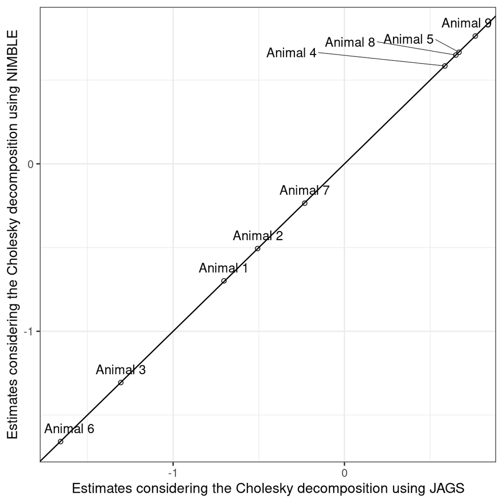

```r
data_comp <-
  data.frame(CholInbJags = estimatesCholInbreeding[c(1:9), 1],
             CholInbNimble = estimatesCholNimble[c(1:9), 1],
             Animal = gl(n = 9,  k = 1,
                         labels = paste0("Animal ", 1:9)))

data_comp %>%
  ggplot(aes(y = CholInbNimble,  x = CholInbJags,  label = Animal)) +
  geom_point(shape = 1,  alpha = 0.9) +
  geom_abline(intercept = 0,  slope = 1) +
  geom_text_repel(
    nudge_y      = 0.05,
    direction    = "x",
    vjust        = 0,
    segment.size = 0.2) +
  ylab("Estimates considering the Cholesky decomposition using NIMBLE") +
  xlab("Estimates considering the Cholesky decomposition using JAGS") +
  theme_bw(base_size = 12)
```

```r
data_diff <- data.frame(
  Parameter = rownames(estimatesCholInbreeding)[c(1:9, 11:12)],
  Difference = estimatesCholNimble[c(1:9,  11, 12), 1] -
    estimatesCholInbreeding[c(1:9,  11, 12), 1],
  Ratio = estimatesCholNimble[c(1:9,  11, 12), 1]/
    estimatesCholInbreeding[c(1:9,  11, 12), 1])

data_diff %>%
  kbl(
    caption = "Difference and ratio between parameter estimates",
    digits = 4,
  ) %>%
  kable_paper("hover", full_width = F) %>%
  column_spec(2, color = "white",
              background = spec_color(data_diff[,2], end = 0.7),
              popover = paste("am:", data_diff[,2])) %>%
  column_spec(3, color = "white",
              background = spec_color(data_diff[,2], end = 0.7),
              popover = paste("am:", data_diff[,3]))
```

Table 8.1: Difference and ratio between parameter estimates

| Parameter | Difference | Ratio |
| --- | --- | --- |
| a[1] | 0.0044 | 0.9937 |
| a[2] | 0.0009 | 0.9982 |
| a[3] | -0.0009 | 1.0007 |
| a[4] | -0.0015 | 0.9974 |
| a[5] | -0.0022 | 0.9967 |
| a[6] | -0.0019 | 1.0011 |
| a[7] | -0.0031 | 1.0134 |
| a[8] | -0.0006 | 0.9991 |
| a[9] | -0.0003 | 0.9996 |
| b[1] | -0.0027 | 1.0000 |
| b[2] | 0.0034 | 1.0000 |

In our small example with only $n=9$ individuals, JAGS takes 2.647 seconds to draw 60,000 samples, while NIMBLE takes 2.924 seconds to draw 54,000 samples using the same BUGS model. Based on this performance, JAGS may be preferred for analyzing small data sets, as it is faster due to not needing to compile the model as NIMBLE does. However, this conclusion may not extend to more complex data sets, as NIMBLE leverages a `C++` compiler to optimize performance. Additionally, the choice of which package to use may also depend on other factors, such as ease of use and available features.

It is also important to note that the reported results may change if we significantly increase the number of samples drawn in the MCMC procedure. Therefore, it is recommended to carefully evaluate the performance of both JAGS and NIMBLE for the specific analysis and data set at hand, including running simulations to assess the sensitivity of the results to the choice of software package and other modeling assumptions.

# 9 The effective number of simulation draws based on JAGS program

We can compute an estimate of the effective number of independent simulation draws for any estimator of interest, denoted here as $E(\mu|y) = \bar{\mu}$ (Gelman et al. 2014). Assuming that we have $n$ simulation draws in the $m$-th MCMC chain, $m = 1, 2, \ldots, M$, we would have a total of $mn$ independent samples from the $m$ MCMC chains if there is no autocorrelation. Therefore, an unbiased estimate of the posterior variance is $Var(\bar{\mu}) = \frac{Var(\mu|y)}{nm}$. However, if there is autocorrelation present in the chain, we can use an estimator of the effective sample size ($n_{eff}$) defined as
$$\widehat{n}_{eff} = \frac{mn}{1 + 2\sum_{t=1}^{T}\widehat{\rho}_{t}},$$
where $\widehat{\rho}t$ is the estimator of the correlation of the sequence $\mu$ at lag $t$, as described by Gelman et al. (2014). Ideally, we want $\widehat{n}{eff}$ to be close to $mn$ or at least a good approximation of it, which happens when $\sum_{t=1}^{T}\widehat{\rho}_{t} \approx 0$.

Table 9.1: Estimate of the effective sample size ratio ($\widehat{R}_{eff}$) for each parameter in the model

| Model | Type | $\widehat{R}_{eff}$ a[1] | $\widehat{R}_{eff}$ a[2] | $\widehat{R}_{eff}$ a[3] | $\widehat{R}_{eff}$ a[4] | $\widehat{R}_{eff}$ a[5] | $\widehat{R}_{eff}$ a[6] | $\widehat{R}_{eff}$ a[7] | $\widehat{R}_{eff}$ a[8] | $\widehat{R}_{eff}$ a[9] | $\widehat{R}_{eff}$ b[1] | $\widehat{R}_{eff}$ b[2] |
| --- | --- | --- | --- | --- | --- | --- | --- | --- | --- | --- | --- | --- |
| m1 | No Inbreeding | 0.9975 | 0.8890 | 0.8723 | 0.9068 | 0.8954 | 0.8645 | 0.8632 | 0.9856 | 0.9002 | 0.9326 | 0.9060 |
| m2 | Inbreeding | 0.9888 | 0.8774 | 0.8537 | 0.8981 | 0.8784 | 0.8488 | 0.8383 | 0.9856 | 0.8878 | 0.9248 | 0.8969 |
| m3 | Inbreeding + Cholesky Decomposition | 1.0000 | 1.0069 | 1.0078 | 1.0000 | 1.0000 | 1.0000 | 0.9836 | 1.0228 | 1.0000 | 1.0000 | 0.9958 |
| m4 | Inbreeding + Cholesky Decomposition + Reording Pedigree | 1.0000 | 0.9920 | 0.9920 | 1.0000 | 0.9883 | 1.0189 | 0.9842 | 1.0227 | 0.9677 | 1.0000 | 1.0000 |
| m5 | Inbreeding + Cholesky Decomposition + Zstar | NA | 1.0000 | 1.0000 | 1.0126 | 1.0000 | 0.9834 | NA | NA | 1.0000 | 1.0000 | 1.0000 |
| m6 | Inbreeding + Zstar + SVD | NA | 1.0000 | 1.0462 | 1.0092 | 1.0127 | 0.9923 | NA | NA | 1.0000 | 1.0000 | 1.0000 |

# 10 Computing cost

Below are two variants of the animal model with transformed additive genetic values, proposed by Damgaard (2007b), which were rewritten and compared for speed and mixing with the proposed implementation in `AnimalModelBUGSVar`). The main difference between the two approaches is the method used to sample from the normal distribution with mean equal to the parent average and variance equal to the precision. In the first variant (`Variantes 1`), the normal distribution is obtained by transforming a standard normal distribution with the appropriate scaling factors. In the second variant (`Variantes 2`), a gamma distribution is used to sample the precision and the normal distribution is obtained by scaling a standard normal distribution with the square root of the precision and adding the parent average. However, both variants are based on the same idea of using transformed additive genetic values that are independent a priori.

It should be noted that the original implementations of Damgaard (2007b) and Waldmann (2009b) were not tested because they are not generic. Moreover, the proposed implementation in `AnimalModelBUGSVar`) is shown to be faster and has better mixing compared to Damgaard (2007b), according to the results of the comparison.

```r
# Variant 1
AnimalModelBUGSVariant1Var <- function()
{
  ## Priors - precision parameters
  tau2e ~ dgamma(0.001, 0.001)
  tau2a ~ dgamma(0.001, 0.001)
  sigma2e <- pow(tau2e, -1)
  sigma2a <- pow(tau2a, -1)

  ## Transformed additive genetic values - variant 1
  for(k in 1:nI) {
    u[k] ~ dnorm(0, tau2a)
    a[id[k]] <- u[k] * wsqr[id[k]] +
      0.5 * (a[fid[k]] + a[mid[k]])
    }
  a[nU] <- 0 # NULL (zero) holder

  ## Location priors
  for(j in 1:nB) {
    b[j] ~ dnorm(0, 1.0E-6)
  }

  ## Phenotypes
  for(i in 1:nY) {
    y[i] ~ dnorm(mu[i], tau2e)
    mu[i] <- inprod(x[i, ], b[]) + a[idy[i]]
  }
}
```

```r
# Variant 2
AnimalModelBUGSVariant2Var <- function()
{
  ## Priors - precision parameters
  tau2e ~ dgamma(0.001, 0.001)
  tau2a ~ dgamma(0.001, 0.001)
  sigma2e <- pow(tau2e, -1)
  sigma2a <- pow(tau2a, -1)

  ## Transformed additive genetic values - variant 2
  sigmaa <- pow(tau2a, -2)
  for(k in 1:nI) {
    u[k] ~ dnorm(0, 1)
    a[id[k]] <- u[k] * wsqr[id[k]] * sigmaa +
      0.5 * (a[fid[k]] + a[mid[k]])
    }
  a[nU] <- 0 # NULL (zero) holder

  ## Location priors
  for(j in 1:nB) {
    b[j] ~ dnorm(0, 1.0E-6)
  }

  ## Phenotypes
  for(i in 1:nY) {
    y[i] ~ dnorm(mu[i], tau2e)
    mu[i] <- inprod(x[i, ], b[]) + a[idy[i]]
  }
}
```

Consider now the code below, which shows an animal model with a reparameterized design matrix $\mathbf{Z}$.

```
 1 ## Transformed additive genetic values
 2 for(k in 1:nI) { u[k] ~ dnorm(0, tau2a) }
 3
 4 ## Location priors
 5 for(j in 1:nB) { b[j] ~ dnorm(0, 1.0E-6) }
 6
 7 ## Phenotypes
 8 for(i in 1:nY) {
 9   y[i] ~ dnorm(mu[i], tau2e)
10   mu[i] <- inprod(x[i, ], b[]) + inprod(u[], ZStar[i, ])
11 }
```

The implemented functions `AnimalModelBUGSVar`, `Variantes 1`, and `Variantes 2`) were tested on a simple example described in section 1. The tests were performed using two approaches, one with assumed known variances and one with variances unknown in addition to other model parameters ($\mathbf{b}$ and $\mathbf{a}$).

To evaluate the efficiency of the MCMC algorithms for generating accurate posterior samples in a Bayesian analysis, the sampling time reported by JAGS was collected, and an effective sample size ($n_{eff}$) was computed for each parameter using the CODA program Plummer et al. (2009). The effective sample size is almost always smaller than the sample size due to autocorrelations between subsequent samples in the Markov chain (e.g. Kass et al. (1998)). We are interested in the MCMC pace or computing cost per sample, which measures the average time needed to generate each effectively independent sample, to evaluate algorithm efficiency.

Therefore, the computing cost per $N_{s}$ samples for the parameter $p$ $\left(c_{p}\right)$ was evaluated as $c_p=N_{s} \times t_{n}/n_{eff}^{(p)}$, where $t_{n}$ is the time spent for drawing $n$ samples. Considering the model has $P$ parameters, the average computing cost per sample was summarized as $\bar{c}=\frac{N_{s} \times t_{n}}{P}\sum_{p=1}^{P}1/n_{eff}^{(p)}$, where $n_{eff}^{(p)}$ is the $n_{eff}$ for the $p$th parameter. However, often one or few parameters may have a worse mixing than the others and, consequently, limit the ability to decide which model should be chosen. For this reason, the maximum computing cost per $N_{s}$ samples ($c_{max} = \max\lbrace{c_{p}\rbrace}_{p=1}^{P}$) was also considered, representing the longest time taken to generate each effectively independent sample.

All computations were performed on a Dell Inspiron 17 7000 with a 10$^{\tiny \mbox{th}}$ Generation Intel$\circledR$ Core$^{\tiny\mbox{TM}}$ i7 processor, 1.80GHz $\times$ four-processor speed, 16GB random access memory (RAM) plus 20GB of swap space, 64-bit integers, and the platform used is a Linux Mint 19.2 Cinnamon system version 5.2.2-050202-generic.

## 10.1 Example 1

We are running three chains, each of one has chain length, burn-in, and thinning rate were arbitrarily set to 20,000, 30,000, and 15, respectively, and the data `example`, which can be seen below:

```r
example
```

| individual | father | mother | phenotype | group |
| --- | --- | --- | --- | --- |
| 1 | NA | NA | NA | NA |
| 2 | NA | NA | 105 | 1 |
| 3 | 2 | 1 | 98 | 1 |
| 4 | 2 | NA | 101 | 2 |
| 5 | 4 | 3 | 106 | 2 |
| 6 | 2 | 3 | 93 | 2 |
| 7 | 5 | 6 | NA | NA |
| 8 | NA | NA | NA | NA |
| 9 | 7 | 8 | 109 | 1 |

Table 10.1: Effect of animal model (known variances) implementation in JAGS using the mean and standard error of sampling time (t) in seconds, computing cost per 10,000 samples ($c_{p}=10,000 \times t_{n}/n_{eff}$), mean computing cost per 10,000 samples ($\bar{c}$), and maximum computing cost per 10,000 samples ($c_{max}$) based on 50 models fitted using three chains each considering a length of 20,000, burn-in set to 30,000, and thinning to 15

| Model | Type | Time Mean | Time SE | Computing cost per sample (c) a[1] | Computing cost per sample (c) a[2] | Computing cost per sample (c) a[3] | Computing cost per sample (c) a[4] | Computing cost per sample (c) a[5] | Computing cost per sample (c) a[6] | Computing cost per sample (c) a[7] | Computing cost per sample (c) a[8] | Computing cost per sample (c) a[9] | Computing cost per sample (c) b[1] | Computing cost per sample (c) b[2] | cost_Mean | cost_max |
| --- | --- | --- | --- | --- | --- | --- | --- | --- | --- | --- | --- | --- | --- | --- | --- | --- |
| m1 | No Inbreeding | 1.2168 | 0.0078 | 0.2033 | 0.2281 | 0.2325 | 0.2237 | 0.2265 | 0.2346 | 0.2349 | 0.2058 | 0.2253 | 0.2175 | 0.2239 | 0.2233 | 0.2349 |
| m2 | Inbreeding | 1.1781 | 0.0285 | 0.1986 | 0.2238 | 0.2300 | 0.2186 | 0.2235 | 0.2313 | 0.2342 | 0.1992 | 0.2212 | 0.2123 | 0.2189 | 0.2192 | 0.2342 |
| m3 | Inbreeding + Cholesky Decomposition | 1.5529 | 0.0349 | 0.2588 | 0.2570 | 0.2568 | 0.2588 | 0.2588 | 0.2588 | 0.2631 | 0.2531 | 0.2588 | 0.2588 | 0.2599 | 0.2584 | 0.2631 |
| m4 | Inbreeding + Cholesky Decomposition (Variant 1) | 2.7878 | 0.0725 | 0.4646 | 0.4614 | 0.4610 | 0.4646 | 0.4646 | 0.4646 | 0.4724 | 0.4543 | 0.4646 | 0.4646 | 0.4666 | 0.4640 | 0.4724 |
| m5 | Inbreeding + Cholesky Decomposition (Variant 2) | 2.7865 | 0.0915 | 0.4644 | 0.4644 | 0.4644 | 0.4644 | 0.4644 | 0.4644 | 0.4594 | 0.4505 | 0.4703 | 0.4655 | 0.4644 | 0.4633 | 0.4703 |
| m6 | Inbreeding + Cholesky Decomposition + Reording Pedigree | 1.4767 | 0.0267 | 0.2461 | 0.2481 | 0.2481 | 0.2461 | 0.2490 | 0.2416 | 0.2501 | 0.2407 | 0.2543 | 0.2461 | 0.2461 | 0.2469 | 0.2543 |
| m7 | Inbreeding + Cholesky Decomposition + Zstar | 1.2577 | 0.0254 | NA | 0.2096 | 0.2096 | 0.2070 | 0.2096 | 0.2132 | NA | NA | 0.2096 | 0.2096 | 0.2096 | 0.2097 | 0.2132 |
| m8 | Inbreeding + Zstar + SVD | 1.2598 | 0.0318 | NA | 0.2100 | 0.2007 | 0.2081 | 0.2073 | 0.2116 | NA | NA | 0.2100 | 0.2100 | 0.2100 | 0.2084 | 0.2116 |

Table 10.2: Effect of animal model (unknown variances) implementation in JAGS using the mean and standard error of sampling time (t) in seconds, computing cost per 10,000 samples ($c_{p}=10,000 \times t_{n}/n_{eff}$), mean computing cost per 10,000 samples ($\bar{c}$), and maximum computing cost per 10,000 samples ($c_{max}$) based on 50 models fitted using three chains each considering a length of 20,000, burn-in set to 30,000, and thinning to 15

| Model | Type | Time Mean | Time SE | Computing cost per sample (c) a[1] | Computing cost per sample (c) a[2] | Computing cost per sample (c) a[3] | Computing cost per sample (c) a[4] | Computing cost per sample (c) a[5] | Computing cost per sample (c) a[6] | Computing cost per sample (c) a[7] | Computing cost per sample (c) a[8] | Computing cost per sample (c) a[9] | Computing cost per sample (c) b[1] | Computing cost per sample (c) b[2] | cost_Mean | cost_max |
| --- | --- | --- | --- | --- | --- | --- | --- | --- | --- | --- | --- | --- | --- | --- | --- | --- |
| m1 | No Inbreeding | 2.2973 | 0.0847 | 1.0568 | 4.9257 | 5.0535 | 5.6073 | 5.8800 | 5.5331 | 3.7477 | 0.7853 | 5.0837 | 3.7550 | 4.3859 | 4.1649 | 5.8800 |
| m2 | Inbreeding | 2.5375 | 0.0819 | 1.1750 | 5.5892 | 5.7894 | 6.3820 | 6.6601 | 6.1996 | 4.5385 | 0.9712 | 5.8833 | 4.2892 | 5.0148 | 4.7720 | 6.6601 |
| m3 | Inbreeding + Cholesky Decomposition | 2.6787 | 0.0947 | 3.2560 | 4.6798 | 4.9114 | 4.7885 | 5.0266 | 4.8739 | 4.0257 | 2.3665 | 4.8109 | 3.6795 | 3.9214 | 4.2127 | 5.0266 |
| m4 | Inbreeding + Cholesky Decomposition (Variant 1) | 2.8721 | 0.0823 | 3.4911 | 5.0177 | 5.2661 | 5.1343 | 5.3896 | 5.2259 | 4.3164 | 2.5374 | 5.1583 | 3.9452 | 4.2046 | 4.5170 | 5.3896 |
| m5 | Inbreeding + Cholesky Decomposition (Variant 2) | 8.0390 | 0.2557 | 10.0400 | 16.3162 | 16.7549 | 16.2535 | 17.5409 | 17.2215 | 14.7640 | 11.2073 | 17.1407 | 9.3227 | 9.8384 | 14.2182 | 17.5409 |
| m6 | Inbreeding + Cholesky Decomposition + Reording Pedigree | 2.3657 | 0.1066 | 3.0431 | 4.6697 | 4.6734 | 4.6468 | 4.7125 | 4.6799 | 4.0322 | 2.5079 | 4.6762 | 3.5489 | 3.6362 | 4.0752 | 4.7125 |
| m7 | Inbreeding + Cholesky Decomposition + Zstar | 2.6427 | 0.0696 | NA | 5.4918 | 4.5485 | 4.3096 | 4.1305 | 3.6857 | NA | NA | 4.3061 | 4.2541 | 4.1676 | 4.3617 | 5.4918 |
| m8 | Inbreeding + Zstar + SVD | 2.2873 | 0.0841 | NA | 5.5732 | 3.4240 | 3.4587 | 1.2405 | 3.3696 | NA | NA | 3.1294 | 3.9118 | 4.3042 | 3.5514 | 5.5732 |

Shariati and Sorensen (2009b) conducted extensive tests of various MCMC samplers for the animal model and concluded that no single sampler was the best in all scenarios. However, they found that transformed and blocked samplers could be beneficial when there are large posterior correlations between the parameters.

## 10.2 Example 2

Let us now evaluate the performance of all model implementations using a more complex example with 5,000 to 10,000 animals. While the example is more complex, the underlying breeding scheme remains simple. We considered two approaches: one assuming known variances and the other assuming unknown variances along with other model parameters such as year and sex effects. We ran three chains with a chain length, burn-in, and thinning rate per chain of 5,000, 3,000, and 10, respectively.

### 10.2.1 Simulation procedure

We simulate a simple beef cattle scheme using the `AlphaSimR` (Gaynor, Gorjanc, and Hickey 2020) package and the work proposed by Lourenco et al. (2015) to set up initial parameter values. The simulated population has 1,000 animals (500 females and 500 males) per generation, where the generation $F_0$ (founders) was generated using the function `runMacs()` to produce founder haplotypes. We also considered ten chromosomes, 1,000 QLT per chromosome, 5,000 SNPs per chromosome, and nine generations. The mean genetic value for birth weight (BiW) was set up to 40 kg, genetic variance equal to 20.25 kg$^2$, and heritability of $0.4$. Furthermore, we also established that males have 1 kilogram more than females on average.

```r
#-----------------------------------------------------------------------
# Definitions
#-----------------------------------------------------------------------
nInd = 1000 # number of individuals
nQtl = 10^3 # number of QTL's / Chromosome
nSnp = 5*10^3 # number of SNPs / Chromosome
nChr = 10 # number of Chromosomes

# Number of Generations
ngen <- 9

# Founders parameters
meanG <- 40 # mean genetic value for the trait
meanSexDiff <- 1 # mean difference between sexes

sigma2g <- 4.5^2 # genetic variance

# Heritability
h2 <- 0.4

# Error
sigma2e <- sigma2g*(1/h2 - 1)

#-----------------------------------------------------------------------
# Haplotypes
#-----------------------------------------------------------------------
founderPop <- runMacs(nInd = nInd,  nChr = nChr, segSites = nQtl + nSnp,
                     species = "CATTLE", ploidy = 2L)
#save(founderPop, file = "haplotypes.RData")
#load(file = "haplotypes.RData")
#-----------------------------------------------------------------------
# Parameters
#-----------------------------------------------------------------------
SP <- SimParam$new(founderPop)

#-----------------------------------------------------------------------
# Quantitative trait (A = only have additive effects)
#-----------------------------------------------------------------------
SP$addTraitA(nQtlPerChr = nQtl,  mean = meanG,  var = sigma2g)

#-----------------------------------------------------------------------
# How sexes are determined in the simulation
## Sistematic assignment to ensure same number of males and females
#-----------------------------------------------------------------------
SP$setSexes("yes_sys")
#-----------------------------------------------------------------------
# Add SNPs Chip
#-----------------------------------------------------------------------
SP$addSnpChip(nSnp)
```

Each year, we generate phenotype data, estimate breeding values, select $10\%$ of the best males, mate them with all-female within a generation, and generate progeny, including their pedigree.

```r
founders <- newPop(founderPop)

# Males
SelMales <- founders[founders@sex == "M"]

# Females
SelFemales = founders[founders@sex == "F"]

nDams <- nInd/2 # no selection
nSires <- 0.1 * nInd/2  # Top 10%

# Phenotypes
SelMales = setPheno(SelMales, varE = sigma2e)
SelMales@pheno = SelMales@pheno + meanSexDiff
SelFemales = setPheno(SelFemales, varE = sigma2e)

RecSys <- RecVar <- NULL
generation <- 0
year <- 0

RecSys <- RecSysMaleFemale(RecSys, SelMales)
RecSys <- RecSysMaleFemale(RecSys, SelFemales)
RecVar <- PullSumm(RecVar, SelMales)
RecVar <- PullSumm(RecVar, SelFemales)

for(generation in 1:ngen){
  Program ="Standard"
  cat("Evaluating", Program,": ", generation,"\n")
  year <- year + 1

  # Mate initial Sires and Dams
  pop_start <- randCross(pop=c(SelMales, SelFemales),
                         nCrosses = nDams, nProgeny = 2)

  # Select next generation based on genetic value
  # Males
  pop_males <- pop_start[pop_start@sex == "M"]

  # Females
  #SelFemales <- setPheno(SelFemales, h2 = h2)
  pop_females = pop_start[pop_start@sex == "F"]

  # Phenotype
  pop_males = setPheno(pop_males, varE = sigma2e)
  pop_males@pheno = pop_males@pheno + meanSexDiff

  pop_females = setPheno(pop_females, varE = sigma2e)

  # Dataset - trible
  RecSys <- RecSysMaleFemale(RecSys, pop_males)
  RecVar <- PullSumm(RecVar, pop_males)

  RecSys = RecSysMaleFemale(RecSys, pop_females)
  RecVar <- PullSumm(RecVar, pop_females)

  # pop_start
  pop_start@sex

  # Selection for the next mate
  SelMales <- selectInd(pop_males, nSires, use = "pheno",
                          sex = "M")
  SelFemales <- pop_females

}

example <- RecSys
example$phenotype <- as.numeric(example$pheno)

example$sex <- as.factor(example$sex)
example <- example %>%
  mutate_if(is.character, as.numeric)

example <- example[, c(2:4,6,5,9)]

# Father and Mother - changing 0 to NA
example <- example %>%
  mutate(father = na_if(father, 0)) %>%
  mutate(mother = na_if(mother, 0))

# ordering pedigree from 1:n
nI <- nrow(example)
nI==length(unique(example$ind))

example$index <- seq(1:nI)
seq <- paste0(seq(1:nI),"A")
for(i in 1:nI){
  t_n <- example$ind[i]
  example$father[example$father == t_n] <- seq[i]
  example$mother[example$mother == t_n] <- seq[i]
  example$ind[example$ind == t_n] <- seq[i]
}

# removing the letter A
example$ind <- as.numeric(gsub("([0-9]+).*$", "\\1", example$ind))
example$father <- as.numeric(gsub("([0-9]+).*$", "\\1", example$father))
example$mother <- as.numeric(gsub("([0-9]+).*$", "\\1", example$mother))

example <- example[,c(1:6)]
example$year <- as.factor(example$year)

example %>%
  saveRDS(file = paste0("animal_sim",ngen+1,".RDS"))

save(RecSys, RecVar, file = paste0("animal_simRecs",ngen+1,".RData"))
```

The dataset and its structure can be seen bellow:

```r
example2 <- readRDS(file = "./datasets/animal_sim10.RDS")
example2
```

| ind | father | mother | year | sex | phenotype |
| --- | --- | --- | --- | --- | --- |
| 1 | NA | NA | 0 | M | 37.66915 |
| 2 | NA | NA | 0 | M | 35.79590 |
| 3 | NA | NA | 0 | M | 28.42813 |
| 4 | NA | NA | 0 | M | 33.62726 |
| 5 | NA | NA | 0 | M | 32.86620 |
| 6 | NA | NA | 0 | M | 31.63590 |
| 7 | NA | NA | 0 | M | 38.84672 |
| 8 | NA | NA | 0 | M | 33.30010 |
| 9 | NA | NA | 0 | M | 38.98282 |
| 10 | NA | NA | 0 | M | 45.98674 |

[output cut: 9990 more lines]

```r
str(example2)
```

```
## tibble [10,000 × 6] (S3: tbl_df/tbl/data.frame)
##  $ ind      : num [1:10000] 1 2 3 4 5 6 7 8 9 10 ...
##  $ father   : num [1:10000] NA NA NA NA NA NA NA NA NA NA ...
##  $ mother   : num [1:10000] NA NA NA NA NA NA NA NA NA NA ...
##  $ year     : Factor w/ 10 levels "0","1","2","3",..: 1 1 1 1 1 1 1 1 1 1 ...
##  $ sex      : Factor w/ 2 levels "F","M": 2 2 2 2 2 2 2 2 2 2 ...
##  $ phenotype: num [1:10000] 37.7 35.8 28.4 33.6 32.9 ...
```

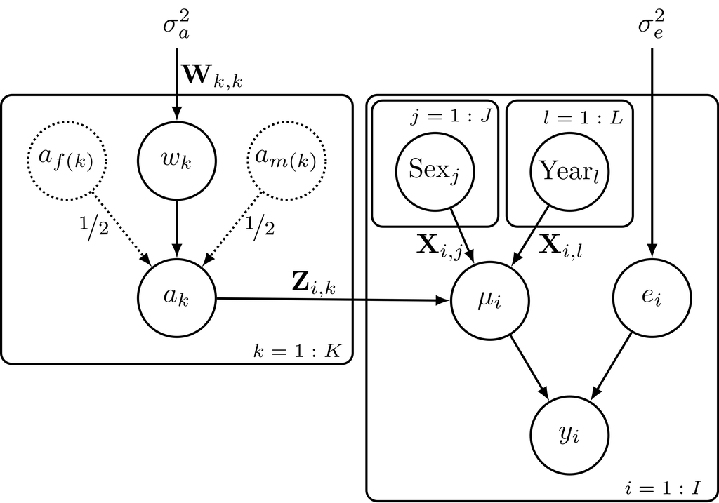

Figure 10.1: Directed acyclic graph of animal model with $K$ individuals and $I$ phenotypic records considering fixed effects of Sex ($\mbox{Sex}_{j}$) and Year ($\mbox{Year}_{l}$), and a representation of Mendelian sampling terms ($w_k$) and error term ($e_i$), where $\sigma_{a}^{2}$ is the genetic variance, $a_{f(k)}$ and $a_{m(k)}$ are parents’ breeding value, $\mu_{i}$ is the linear predictor, and $\sigma_{e}^{2}$ variance of the error term. We are ommiting the intercept term in the linear predictor.

## 10.3 Computing Cost

1. **Basic Animal model**

```r
# Variance unknown
AnimalModelBUGSVar
```

```
## function()
## {
##   ## Priors - precision parameters
##   tau2e ~ dgamma(0.001, 0.001)
##   tau2a ~ dgamma(0.001, 0.001)
##   sigma2e <- pow(tau2e, -1)
##   sigma2a <- pow(tau2a, -1)
##
##   ## Additive genetic values
##   for(k in 1:nI) {
##     a[id[k]] ~ dnorm(pa[id[k]], Xtau2a[id[k]])
##     pa[id[k]] <- 0.5 * (a[fid[k]] + a[mid[k]])
##     Xtau2a[id[k]] <- winv[id[k]] * tau2a
##   }
##   a[nU] <- 0 # NULL (zero) holder
##
##   ## Fixed Effects
##   for(j in 1:nB) { b[j] ~ dnorm(0, 1.0E-6) }
##
##   ## Phenotypes
##   for(i in 1:nY) {
##     y[i] ~ dnorm(mu[i], tau2e)
##     mu[i] <- inprod(x[i, ], b[]) + a[idy[i]]
##   }
## }
```

- **Without accounting for inbreeding:**

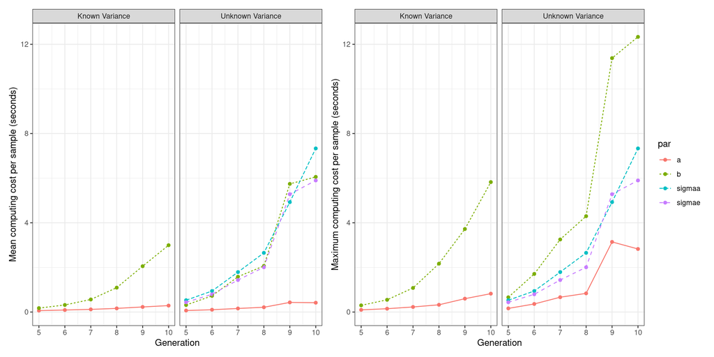

Figure 10.2: Mean and Maximum computing cost per sample (in seconds) for additive breeding values ($a$), fixed effect terms ($b$), additive variance ($\sigma^2_a$), and error term variance ($\sigma_{e}^2$) without accounting for inbreeding

```r
dataNoInb <- do.call('rbind',
                     lapply(c("./Results/Large_Example/ESSNoInb.RDS",
                              "./Results/Large_Example/ESSNoInbVar.RDS"), readRDS))
dataNoInb$model <- as.factor(dataNoInb$model)

g1 <- dataNoInb %>%
  ggplot(aes(y= cost_mean, x= Generation)) +
  geom_point(aes(colour = par)) +
  geom_line(aes(linetype = par, colour = par)) +
  xlab("Generation") +
  ylab("Mean computing cost per sample (seconds)")+
  ylim(0, max(dataNoInb$cost_max)) +
  facet_wrap(~model)+
  theme_bw() +
  theme(legend.position = "none")

g2 <- dataNoInb %>%
  ggplot(aes(y= cost_max, x= Generation)) +
  geom_point(aes(colour = par)) +
  geom_line(aes(linetype = par, colour = par)) +
  xlab("Generation") +
  ylim(0, max(dataNoInb$cost_max)) +
  ylab("Maximum computing cost per sample (seconds)")+
  facet_wrap(~model)+
  theme_bw()
g1+g2
```

- **Accounting for inbreeding:**

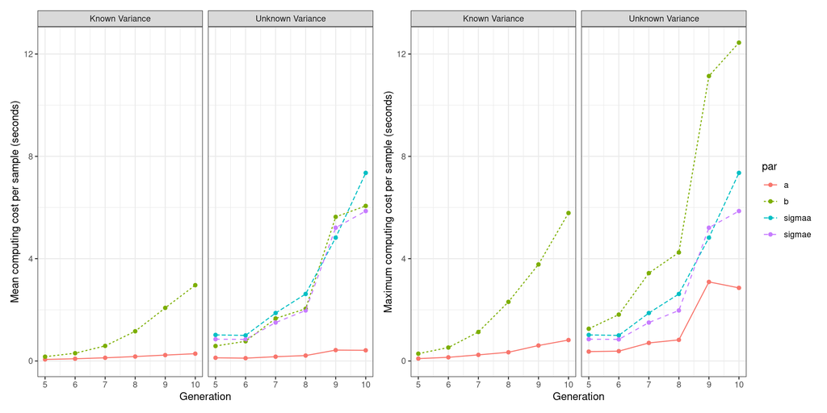

Figure 10.3: Mean and Maximum computing cost per sample (in seconds) for additive breeding values ($a$), fixed effect terms ($b$), additive variance ($\sigma^2_a$), and error term variance ($\sigma_{e}^2$) accounting for inbreeding

```r
dataInb <- do.call('rbind',
                     lapply(c("./Results/Large_Example/ESSInb.RDS",
                              "./Results/Large_Example/ESSInbVar.RDS"), readRDS))
dataInb$model <- as.factor(dataInb$model)

g1 <- dataInb %>%
  ggplot(aes(y= cost_mean, x= Generation)) +
  geom_point(aes(colour = par)) +
  geom_line(aes(linetype = par, colour = par)) +
  xlab("Generation") +
  ylab("Mean computing cost per sample (seconds)")+
  ylim(0, max(dataInb$cost_max)) +
  facet_wrap(~model)+
  theme_bw() +
  theme(legend.position = "none")

g2 <- dataInb %>%
  ggplot(aes(y= cost_max, x= Generation)) +
  geom_point(aes(colour = par)) +
  geom_line(aes(linetype = par, colour = par)) +
  xlab("Generation") +
  ylim(0, max(dataInb$cost_max)) +
  ylab("Maximum computing cost per sample (seconds)")+
  facet_wrap(~model)+
  theme_bw()
g1+g2
```

2. **Animal model using Cholesky decompostion of the NRM**

```r
# VAriance unknown
AnimalModelBUGSCholVar
```

```
## function()
## {
##   ## Variance priors
##   tau2e ~ dgamma(0.001, 0.001)
##   tau2a ~ dgamma(0.001, 0.001)
##   sigma2e <- 1 / tau2e
##   sigma2a <- 1 / tau2a
##
##   ## Additive genetic values
##   for(k in 1:nI) {
##     u[k] ~ dnorm(0, tau2a)
##     a[id[k]] <- u[k] * wsqr[id[k]] + 0.5 * (a[fid[k]] + a[mid[k]])
##   }
##   a[nU] <- 0 # NULL (zero) holder
##
##   ## Location priors
##   for(j in 1:nB) { b[j] ~ dnorm(0, 1.0E-6) }
##
##   ## Phenotypes
##   for(i in 1:nY) {
##     y[i] ~ dnorm(mu[i], tau2e)
##     mu[i] <- inprod(x[i, ], b[]) + a[idy[i]]
##   }
## }
```

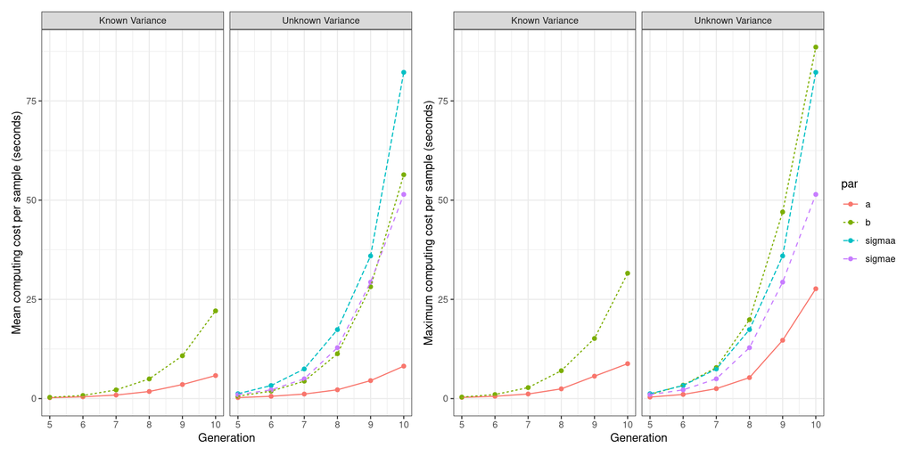

Figure 10.4: Mean and Maximum computing cost per sample (in seconds) for additive breeding values ($a$), fixed effect terms ($b$), additive variance ($\sigma^2_a$), and error term variance ($\sigma_{e}^2$) accounting for inbreeding and using Cholesky decompostion of the NRM

```r
dataChol <- do.call('rbind',
                     lapply(c("./Results/Large_Example/ESSChol.RDS",
                              "./Results/Large_Example/ESSCholVar.RDS"), readRDS))
dataChol$model <- as.factor(dataChol$model)

g1c <- dataChol %>%
  ggplot(aes(y= cost_mean, x= Generation)) +
  geom_point(aes(colour = par)) +
  geom_line(aes(linetype = par, colour = par)) +
  xlab("Generation") +
  ylab("Mean computing cost per sample (seconds)")+
  ylim(0, max(dataChol$cost_max)) +
  facet_wrap(~model)+
  theme_bw() +
  theme(legend.position = "none")

g2c <- dataChol %>%
  ggplot(aes(y= cost_max, x= Generation)) +
  geom_point(aes(colour = par)) +
  geom_line(aes(linetype = par, colour = par)) +
  xlab("Generation") +
  ylim(0, max(dataChol$cost_max)) +
  ylab("Maximum computing cost per sample (seconds)")+
  facet_wrap(~model)+
  theme_bw()
g1c+g2c
```

3. **Animal model variant 1 using Cholesky decompostion of the NRM**

```r
# Variance unknown
AnimalModelBUGSVariant1Var
```

```
## function()
## {
##   ## Priors - precision parameters
##   tau2e ~ dgamma(0.001, 0.001)
##   tau2a ~ dgamma(0.001, 0.001)
##   sigma2e <- pow(tau2e, -1)
##   sigma2a <- pow(tau2a, -1)
##
##   ## Transformed additive genetic values - variant 1
##   for(k in 1:nI) {
##     u[k] ~ dnorm(0, tau2a)
##     a[id[k]] <- u[k] * wsqr[id[k]] +
##       0.5 * (a[fid[k]] + a[mid[k]])
##     }
##   a[nU] <- 0 # NULL (zero) holder
##
##   ## Location priors
##   for(j in 1:nB) {
##     b[j] ~ dnorm(0, 1.0E-6)
##   }
##
##   ## Phenotypes
##   for(i in 1:nY) {
##     y[i] ~ dnorm(mu[i], tau2e)
##     mu[i] <- inprod(x[i, ], b[]) + a[idy[i]]
##   }
## }
```

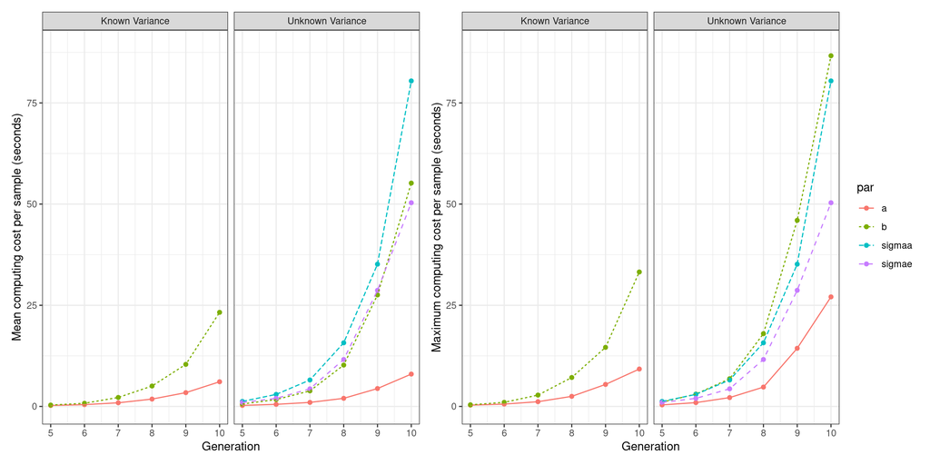

Figure 10.5: Mean and Maximum computing cost per sample (in seconds) for additive breeding values ($a$), fixed effect terms ($b$), additive variance ($\sigma^2_a$), and error term variance ($\sigma_{e}^2$) accounting for inbreeding and using Cholesky decompostion of the NRM (variant 1)

```r
dataCholVar1 <- do.call('rbind',
                     lapply(c("./Results/Large_Example/ESSCholVar1.RDS",
                              "./Results/Large_Example/ESSCholVar1Var.RDS"), readRDS))
dataCholVar1$model <- as.factor(dataCholVar1$model)

g1 <- dataCholVar1 %>%
  ggplot(aes(y= cost_mean, x= Generation)) +
  geom_point(aes(colour = par)) +
  geom_line(aes(linetype = par, colour = par)) +
  xlab("Generation") +
  ylab("Mean computing cost per sample (seconds)")+
  ylim(0, max(dataChol$cost_max)) +
  facet_wrap(~model)+
  theme_bw() +
  theme(legend.position = "none")

g2 <- dataCholVar1 %>%
  ggplot(aes(y= cost_max, x= Generation)) +
  geom_point(aes(colour = par)) +
  geom_line(aes(linetype = par, colour = par)) +
  xlab("Generation") +
  ylim(0, max(dataChol$cost_max)) +
  ylab("Maximum computing cost per sample (seconds)")+
  facet_wrap(~model)+
  theme_bw()
g1+g2
```

4. **Animal model variant 2 using Cholesky decompostion of the NRM**

```r
# Variance unknown
AnimalModelBUGSVariant2Var
```

```
## function()
## {
##   ## Priors - precision parameters
##   tau2e ~ dgamma(0.001, 0.001)
##   tau2a ~ dgamma(0.001, 0.001)
##   sigma2e <- pow(tau2e, -1)
##   sigma2a <- pow(tau2a, -1)
##
##   ## Transformed additive genetic values - variant 2
##   sigmaa <- pow(tau2a, -2)
##   for(k in 1:nI) {
##     u[k] ~ dnorm(0, 1)
##     a[id[k]] <- u[k] * wsqr[id[k]] * sigmaa +
##       0.5 * (a[fid[k]] + a[mid[k]])
##     }
##   a[nU] <- 0 # NULL (zero) holder
##
##   ## Location priors
##   for(j in 1:nB) {
##     b[j] ~ dnorm(0, 1.0E-6)
##   }
##
##   ## Phenotypes
##   for(i in 1:nY) {
##     y[i] ~ dnorm(mu[i], tau2e)
##     mu[i] <- inprod(x[i, ], b[]) + a[idy[i]]
##   }
## }
```

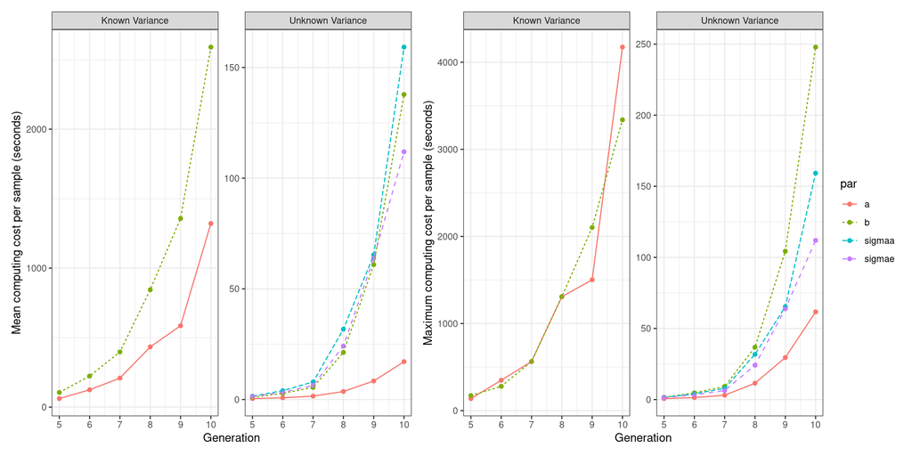

Figure 10.6: Mean and Maximum computing cost per sample (in seconds) for additive breeding values ($a$), fixed effect terms ($b$), additive variance ($\sigma^2_a$), and error term variance ($\sigma_{e}^2$) accounting for inbreeding and using Cholesky decompostion of the NRM (variant 2)

```r
 dataCholVar2 <- do.call('rbind',
                     lapply(c("./Results/Large_Example/ESSCholVar2.RDS",
                              "./Results/Large_Example/ESSCholVar2Var.RDS"), readRDS))
dataCholVar2$model <- as.factor(dataCholVar2$model)

g1 <- dataCholVar2 %>%
  ggplot(aes(y= cost_mean, x= Generation)) +
  geom_point(aes(colour = par)) +
  geom_line(aes(linetype = par, colour = par)) +
  xlab("Generation") +
  ylab("Mean computing cost per sample (seconds)") +
#  ylim(0, max(dataCholVar2$cost_max)) +
  facet_wrap(~model, scales = "free") +
  theme_bw() +
  theme(legend.position = "none")

g2 <- dataCholVar2 %>%
  ggplot(aes(y= cost_max, x= Generation)) +
  geom_point(aes(colour = par)) +
  geom_line(aes(linetype = par, colour = par)) +
  xlab("Generation") +
#  ylim(0, max(dataCholVar2$cost_max)) +
  ylab("Maximum computing cost per sample (seconds)") +
  facet_wrap(~model, scales = "free") +
  theme_bw()
g1+g2
```

## 10.4 NIMBLE

To illustrate the cost per effective sample based on the NIMBLE package, we consider the animal model using Cholesky decomposition of the NRM and the Gibbs sampling algorithm. As shown in Figure 10.7, NIMBLE has a lower mean and maximum cost per sample compared to JAGS. Therefore, for more complex DAG models, we recommend using NIMBLE instead of JAGS. Additionally, the `C++` compiler of NIMBLE does an excellent job of speeding up the analysis.

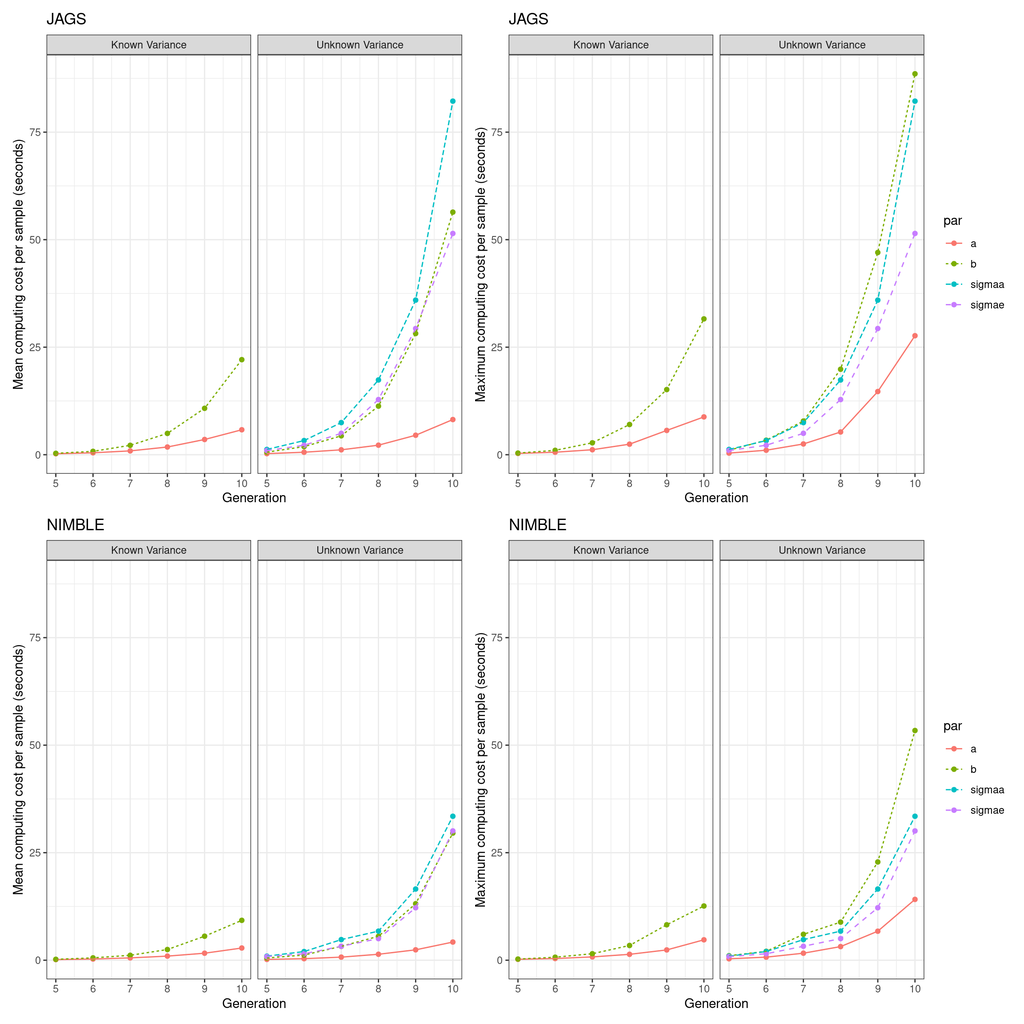

Figure 10.7: Mean and Maximum computing cost per sample (in seconds) for JAGS and NIMBLE considering the additive breeding values ($a$), fixed effect terms ($b$), additive variance ($\sigma^2_a$), and error term variance ($\sigma_{e}^2$) accounting for inbreeding and using Cholesky decompostion of the NRM

```r
data2 <- readRDS("./Results/Large_Example/ESSCholNimble.RDS")
data2$model <- "Known Variance"
saveRDS(data2, file="./Results/Large_Example/ESSCholNimble.RDS")

dataCholNimble <- do.call('rbind',
                     lapply(c("./Results/Large_Example/ESSCholNimble.RDS",
                              "./Results/Large_Example/ESSCholVarNimble.RDS"), readRDS))
dataCholNimble$model <- as.factor(dataCholNimble$model)
dataCholNimble$par <- as.factor(dataCholNimble$par)

g1 <- dataCholNimble %>%
  ggplot(aes(y= cost_mean, x= Generation)) +
  geom_point(aes(colour = par)) +
  geom_line(aes(linetype = par, colour = par)) +
  xlab("Generation") +
  ylab("Mean computing cost per sample (seconds)")+
  ylim(0, max(dataChol$cost_max)) +
  facet_wrap(~model)+
  theme_bw() +
  ggtitle("NIMBLE")+
  theme(legend.position = "none")

g2 <- dataCholNimble %>%
  ggplot(aes(y= cost_max, x= Generation)) +
  geom_point(aes(colour = par)) +
  geom_line(aes(linetype = par, colour = par)) +
  xlab("Generation") +
  ylim(0, max(dataChol$cost_max)) +
  ylab("Maximum computing cost per sample (seconds)")+
  facet_wrap(~model)+
  ggtitle("NIMBLE")+
  theme_bw()

p1 <- g1c + ggtitle("JAGS")
p2 <- g2c + ggtitle("JAGS")
(p1+p2)/(g1+g2)
```

# References

Alfriend, Kyle T., Srinivas R. Vadali, Pini Gurfil, Jonathan P. How, and Louis S. Breger. 2010. “Chapter 3 - The Basics of Analytical Mechanics, Optimization, Control and Estimation.” In *Spacecraft Formation Flying*, edited by Kyle T. Alfriend, Srinivas R. Vadali, Pini Gurfil, Jonathan P. How, and Louis S. Breger, 39–57. Oxford: Butterworth-Heinemann. https://doi.org/10.1016/B978-0-7506-8533-7.00208-6.

Bates, Douglas, and Martin Maechler. 2015. “MatrixModels: Modelling with Sparse And Dense Matrices.” https://CRAN.R-project.org/package=MatrixModels.

Bates, Douglas, and Ana Ines Vazquez. 2014. “Pedigreemm: Pedigree-Based Mixed-Effects Models.” https://CRAN.R-project.org/package=pedigreemm.

Chari, M. V. K., and S. J. Salon. 2000. “11 - SOLUTION OF EQUATIONS.” In *Numerical Methods in Electromagnetism*, edited by M. V. K. Chari and S. J. Salon, 591–706. San Diego: Academic Press. https://doi.org/10.1016/B978-012615760-4/50012-2.

Damgaard, L. H. 2007b. “Technical Note: How to Use Winbugs to Draw Inferences in Animal Models.” *Journal of Animal Science* 85 (6): 1363–68. https://doi.org/10.2527/jas.2006-543.

———. 2007a. “Technical Note: How to Use Winbugs to Draw Inferences in Animal Models.” *Journal of Animal Science* 85 (6): 1363–68. https://doi.org/10.2527/jas.2006-543.

Denwood, Matthew J. 2016. “Runjags: An R Package Providing Interface Utilities, Model Templates, Parallel Computing Methods and Additional Distributions for MCMC Models in JAGS.” *Journal of Statistical Software*, 25.

Gaynor, R Chris, Gregor Gorjanc, and John M Hickey. 2020. “AlphaSimR: An R-Package for Breeding Program Simulations.” *bioRxiv*, 21. https://doi.org/https://doi.org/10.1101/2020.08.10.245167.

Gelman, A. 2006. “Prior Distributions for Variance Parameters in Hierarchical Models.” *Bayesian Analysis* 1 (3): 515–33. http://ba.stat.cmu.edu/journal/2006/vol01/issue03/gelman.pdf.

Gelman, A., J. B. Carlin, H. S. Stern, D. B. Dunson, A Vehtari, and D. B. Rubin. 2014. *Bayesian Data Analysis*. 3rd ed. New York: Taylor & Francis.

Harville, D. A. 1986b. “Using Ordinary Least Squares Software to Compute Combined Intra-Interblock Estimates of Treatment Contrasts.” *American Statistician* 40 (3): 153–57. http://www.jstor.org/stable/2684879.

———. 1986a. “Using Ordinary Least Squares Software to Compute Combined Intra-Interblock Estimates of Treatment Contrasts.” *American Statistician* 40 (3): 153–57. http://www.jstor.org/stable/2684879.

Kass, R. E., B. P. Carlin, A. Gelman, and R. M. Neal. 1998. “Markov Chain Monte Carlo in Practice: A Roundtable Discussion.” *American Statistician* 52 (2): 93–100.

Lin, S. 1999. “Monte Carlo Bayesian Methods for Quantitative Traits.” *Computational Statistics and Data Analysis* 31 (1): 89–108. https://doi.org/10.1016/S0167-9473(99)00006-7.

Lourenco, D A L, S Tsuruta, B O Fragomeni, Y Masuda, I Aguilar, A Legarra, J K Bertrand, et al. 2015. “Genetic Evaluation Using Single-Step Genomic Best Linear Unbiased Predictor in American Angus.” *Journal of Animal Science*, 10. https://doi.org/10.2527/jas2014-8836.

Mehrabani-Yeganeh, H., J. P. Gipson, and L. R. Schaeffer. 2001. “Including Coefficients of Inbreeding in BLUP Evaluation and Its Effect on Response to Selection.” *Journal of Animal Breeding and Genetics-Zeitschrift Fur Tierzuchtung Und Zuchtungsbiologie* 117 (3): 145–51. https://doi.org/10.1046/j.1439-0388.2000.00241.x.

Pedersen, Thomas L. 2020. “Patchwork: The Composer of Plots.” https://CRAN.R-project.org/package=patchwork.

Plummer, M., N. Best, K. Cowles, and K. Vines. 2009. “The CODA R Package: Output Analysis and Diagnostics for McMC.” Manual. http://cran.r-project.org/package=coda.

Quaas, R. L., R. D. Anderson, and A. R. Gilmour. 1984b. *BLUP School Handbook: Use of Mixed Models for Prediction and Estimation of (Co)variance Components*.

———. 1984a. *BLUP School Handbook: Use of Mixed Models for Prediction and Estimation of (Co)variance Components*.

Ren, Kun, and Kenton Russell. 2016. “Formattable: Create ’Formattable’ Data Structures.” https://CRAN.R-project.org/package=formattable.

Shariati, M., and D. Sorensen. 2009b. “Efficiency of Alternative MCMC Strategies Illustrated Using the Reaction Norm Model.” *Journal of Animal Breeding and Genetics-Zeitschrift Fur Tierzuchtung Und Zuchtungsbiologie* 125 (3): 176–86. https://doi.org/10.1111/j.1439-0388.2008.00716.x.

———. 2009a. “Efficiency of Alternative MCMC Strategies Illustrated Using the Reaction Norm Model.” *Journal of Animal Breeding and Genetics-Zeitschrift Fur Tierzuchtung Und Zuchtungsbiologie* 125 (3): 176–86. https://doi.org/10.1111/j.1439-0388.2008.00716.x.

Slowikowski, Kamil. 2020. “Ggrepel: Automatically Position Non-Overlapping Text Labels with ’Ggplot2’.” https://CRAN.R-project.org/package=ggrepel.

Sorensen, D., R. Fernando, and D. Gianola. 2001. “Inferring the Trajectory of Genetic Variance in the Course of Artificial Selection.” *Genetical Research* 77 (1): 83–94. https://doi.org/10.1017/S0016672300004833.

Spiegelhalter, D., A. Thomas, N. Best, and D. Lunn. 2003. *WinBUGS User Manual*. http://www.mrc-bsu.cam.ac.uk/bugs/.

———. 2007. *OpenBUGS User Manual*. http://mathstat.helsinki.fi/openbugs/.

Valpine, Perry de, Christopher J. Paciorek, Daniel Turek, Nick Michaud, Cliff Anderson-Bergman, Fritz Obermeyer, Claudia Wehrhahn Cortes, Abel Rodrìguez, Duncan Temple Lang, and Sally Paganin. 2020. “NIMBLE: MCMC, Particle Filtering, and Programmable Hierarchical Modeling.” https://cran.r-project.org/package=nimble.

Van Vleck, L. D. 1994. “Algorithms for Simulation of Animal Models with Multiple Traits and with Maternal and Non-Additive Genetic Effects.” *Brazil. J. Genet.* 12 (1): 53–57.

Waagepetersen, R., N Ibáñez-Escriche, and D. Sorensen. 2008. “A Comparison of Strategies for Markov Chain Monte Carlo Computation in Quantitative Genetics.” *Genetics Selection Evolution* 40 (1): 161–76. https://doi.org/10.1051/gse:2007042.

Waagepetersen, R., Ibáñez-Escriche N., and D. Sorensen. 2008. “A Comparison of Strategies for Markov Chain Monte Carlo Computation in Quantitative Genetics.” *Genetics Selection Evolution* 40 (1): 161–76. https://doi.org/10.1051/gse:2007042.

Waldmann, P. 2009b. “Easy and Flexible Bayesian Inference of Quantitative Genetic Parameters.” *Evolution* 63 (6): 1640–43. https://doi.org/10.1111/j.1558-5646.2009.00645.x.

———. 2009a. “Easy and Flexible Bayesian Inference of Quantitative Genetic Parameters.” *Evolution* 63 (6): 1640–43. https://doi.org/10.1111/j.1558-5646.2009.00645.x.

Waldmann, P., J. Hallander, F. Hoti, and M. J. Sillanpää. 2008b. “Efficient Markov Chain Monte Carlo Implementation of Bayesian Analysis of Additive and Dominance Genetic Variances in Noninbred Pedigrees.” *Genetics* 179 (2): 1101–12. https://doi.org/10.1534/genetics.107.084160.

———. 2008a. “Efficient Markov Chain Monte Carlo Implementation of Bayesian Analysis of Additive and Dominance Genetic Variances in Noninbred Pedigrees.” *Genetics* 179 (2): 1101–12. https://doi.org/10.1534/genetics.107.084160.

Wickham, Hadley. 2016. *Ggplot2: Elegant Graphics for Data Analysis*. New York: Springer-Verlag. https://ggplot2.tidyverse.org.

Wickham, Hadley, Romain François, Lionel Henry, and Kirill Muller. 2020. “Dplyr: A Grammar of Data Manipulation.” https://CRAN.R-project.org/package=dplyr.

Xie, Yihui. 2020. “Knitr: A General-Purpose Package for Dynamic Report Generation in R.”

Youngflesh, Casey. 2018. “MCMCvis: Tools to Visualize, Manipulate, and Summarize MCMC Output.” *Journal of Open Source Software* 3 (24): 640. 10.21105/joss.00640.

Zhu, Hao. 2020. “kableExtra: Construct Complex Table with ’Kable’ and Pipe Syntax.” https://github.com/haozhu233/kableExtra.